# GLM_ClaimInd

Dudot Lucas - Lapaz Eudes - Moinard Benjamin - Nanoux Louis

2023-02-28

Début habituel pour le code :

```r
summary(freMPL5$Sinistres2)
```

```
##     Min.  1st Qu.   Median     Mean  3rd Qu.     Max.
##   0.0000   0.0000   0.0000   0.2667   0.0000 500.0000
```

```r
set.seed(seed = 2023)
echantillon <- sample(c(TRUE, FALSE), nrow(freMPL5), replace=TRUE, prob=c(0.8,0.2))
train  <- freMPL5[echantillon, ]
test   <- freMPL5[!echantillon, ]
```

# 1) Modélisation de `ClaimInd` (approche binomiale)

L’objectif de cette étude est d’expliquer “ClaimInd” (représenter par la variable $Y$) grâce à $p$ variables explicatives que nous déterminerons.

Le code ci-dessous permet de savoir que l’évènement rare est “l’assuré a eu un sinistre”. Par conséquent, on affecte la valeur 1 à cet évènement et 0 sinon (comme cela est déjà codé).

$Y$ est donc à valeurs dans $\text{{0;1}}$. La loi choisie pour cette modélisation est donc une loi de Bernouilli, avec comme fonction de lien canonique la fonction $logit$.

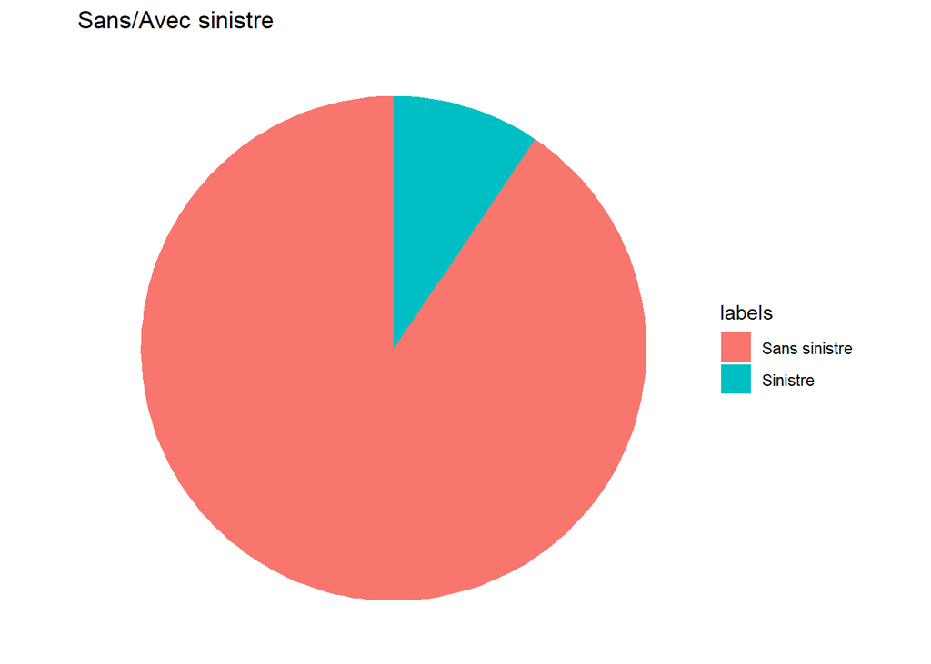

```r
Train_Contingence <- table(train$ClaimInd, train$ClaimInd)

x=c(Train_Contingence[1,1],Train_Contingence[2,2])
labels=c("Sans sinistre","Sinistre")
df=data.frame(x, labels)

ggplot(df, aes(x="", y=x, fill=labels)) +geom_bar(width = 1, stat ="identity") + coord_polar("y", start=0) +theme_void()+ggtitle("Sans/Avec sinistre")
```

La première étape dans la sélection de variables explicatives est l’étude des corrélations entre ses dernières.

Nous avons déjà fait cette étape dans la première partie donc nous allons donner directement le modèle.

Nous prendrons dans un premier temps toutes les variables sauf RecordBeg, RecordEnd, Gender (interdit par la législation française.

Afin de sélectionner au mieux notre modèle, nous devons introduire un critère de sélection.

Le critère $AIC$ d’un modèle $[m]$ est

$$AIC(m)=\frac{n}{2}\log(SCR(m))+m$$

Nous allons introduire plusieurs modèles. Un modèle vide puis des modèles pleins utilisant différentes fonctions de lien.

### Lien log

```r
mod0 <- glm(ClaimInd ~ 1, data = train, family = binomial(link = log))
summary(mod0)
```

```
##
## Call:
## glm(formula = ClaimInd ~ 1, family = binomial(link = log), data = train)
##
## Deviance Residuals:
##     Min       1Q   Median       3Q      Max
## -0.4458  -0.4458  -0.4458  -0.4458   2.1718
##
## Coefficients:
##             Estimate Std. Error z value Pr(>|z|)
## (Intercept) -2.35827    0.02151  -109.6   <2e-16 ***
## ---
## Signif. codes:  0 '***' 0.001 '**' 0.01 '*' 0.05 '.' 0.1 ' ' 1
##
## (Dispersion parameter for binomial family taken to be 1)
##
##     Null deviance: 12946  on 20679  degrees of freedom
## Residual deviance: 12946  on 20679  degrees of freedom
## AIC: 12948
##
## Number of Fisher Scoring iterations: 6
```

```r
2*as.numeric(logLik(mod0))
```

```
## [1] -12946.4
```

```r
modFull <- glm(ClaimInd ~ MariStat+VehUsage+HasKmLimit+ClaimNbResp+ClaimNbNonResp+ClaimNbParking+ClaimNbFireTheft+ClaimNbWindscreen+OutUseNb+Risque+BonusMalus+DrivAge_fact+Categ, data = train, family = binomial(link = log))
summary(modFull)
```

```
##
## Call:
## glm(formula = ClaimInd ~ MariStat + VehUsage + HasKmLimit + ClaimNbResp +
##     ClaimNbNonResp + ClaimNbParking + ClaimNbFireTheft + ClaimNbWindscreen +
##     OutUseNb + Risque + BonusMalus + DrivAge_fact + Categ, family = binomial(link = log),
##     data = train)
##
## Deviance Residuals:
##     Min       1Q   Median       3Q      Max
## -0.9185  -0.4678  -0.4199  -0.3843   2.4453
##
## Coefficients:
##                                 Estimate Std. Error z value Pr(>|z|)
## (Intercept)                    -2.695538   0.255195 -10.563  < 2e-16 ***
## MariStatOther                   0.020266   0.068282   0.297 0.766615
## VehUsagePrivate+trip to office  0.043052   0.076367   0.564 0.572925
## VehUsageProfessional            0.271975   0.089601   3.035 0.002402 **
## VehUsageProfessional run        0.337607   0.131482   2.568 0.010238 *
## HasKmLimit1                    -0.114973   0.095019  -1.210 0.226282
## ClaimNbResp                     0.079508   0.041674   1.908 0.056408 .
## ClaimNbNonResp                  0.130104   0.031005   4.196 2.71e-05 ***
## ClaimNbParking                  0.146679   0.061927   2.369 0.017856 *
## ClaimNbFireTheft                0.119201   0.065932   1.808 0.070618 .
## ClaimNbWindscreen               0.107850   0.028423   3.794 0.000148 ***
## OutUseNb                        0.025535   0.030034   0.850 0.395211
## Risque1                        -0.205098   0.115078  -1.782 0.074709 .
## Risque2                        -0.080190   0.122145  -0.657 0.511496
## Risque3                        -0.007029   0.126023  -0.056 0.955521
## Risque4                         0.180178   0.146593   1.229 0.219033
## BonusMalus                      0.003266   0.001875   1.741 0.081638 .
## DrivAge_fact(25,30]            -0.109366   0.131214  -0.833 0.404568
## DrivAge_fact(30,35]            -0.403049   0.135679  -2.971 0.002972 **
## DrivAge_fact(35,40]            -0.315813   0.138744  -2.276 0.022832 *
## DrivAge_fact(40,45]            -0.202759   0.140460  -1.444 0.148872
## DrivAge_fact(45,50]            -0.251808   0.142112  -1.772 0.076412 .
## DrivAge_fact(50,58]            -0.393587   0.137856  -2.855 0.004303 **
## DrivAge_fact(58,65]            -0.185930   0.147289  -1.262 0.206824
## DrivAge_fact(65,120]           -0.262476   0.162371  -1.617 0.105983
## Categ1                          0.300938   0.126322   2.382 0.017204 *
## Categ2                          0.366014   0.144445   2.534 0.011279 *
## Categ3                          0.349727   0.114927   3.043 0.002342 **
## Categ4                          0.237973   0.148318   1.604 0.108610
## ---
## Signif. codes:  0 '***' 0.001 '**' 0.01 '*' 0.05 '.' 0.1 ' ' 1
##
## (Dispersion parameter for binomial family taken to be 1)
##
##     Null deviance: 12946  on 20679  degrees of freedom
## Residual deviance: 12771  on 20651  degrees of freedom
## AIC: 12829
##
## Number of Fisher Scoring iterations: 6
```

```r
2*as.numeric(logLik(modFull))
```

```
## [1] -12770.65
```

```r
modBoth = step(modFull, mod0, trace=F,direction = c('both'))
summary(modBoth)
```

```
##
## Call:
## glm(formula = ClaimInd ~ VehUsage + ClaimNbResp + ClaimNbNonResp +
##     ClaimNbParking + ClaimNbFireTheft + ClaimNbWindscreen + Risque +
##     BonusMalus + DrivAge_fact + Categ, family = binomial(link = log),
##     data = train)
##
## Deviance Residuals:
##     Min       1Q   Median       3Q      Max
## -0.9201  -0.4673  -0.4200  -0.3840   2.4468
##
## Coefficients:
##                                 Estimate Std. Error z value Pr(>|z|)
## (Intercept)                    -2.688004   0.251977 -10.668  < 2e-16 ***
## VehUsagePrivate+trip to office  0.048958   0.076107   0.643 0.520043
## VehUsageProfessional            0.286846   0.089081   3.220 0.001282 **
## VehUsageProfessional run        0.351349   0.131167   2.679 0.007392 **
## ClaimNbResp                     0.082044   0.041648   1.970 0.048843 *
## ClaimNbNonResp                  0.132863   0.030937   4.295 1.75e-05 ***
## ClaimNbParking                  0.149491   0.061798   2.419 0.015562 *
## ClaimNbFireTheft                0.119622   0.065917   1.815 0.069564 .
## ClaimNbWindscreen               0.110054   0.028344   3.883 0.000103 ***
## Risque1                        -0.210730   0.114993  -1.833 0.066870 .
## Risque2                        -0.086460   0.122042  -0.708 0.478667
## Risque3                        -0.015309   0.125872  -0.122 0.903197
## Risque4                         0.183109   0.146483   1.250 0.211286
## BonusMalus                      0.003276   0.001866   1.756 0.079125 .
## DrivAge_fact(25,30]            -0.104359   0.130198  -0.802 0.422821
## DrivAge_fact(30,35]            -0.396205   0.132980  -2.979 0.002888 **
## DrivAge_fact(35,40]            -0.307409   0.135419  -2.270 0.023204 *
## DrivAge_fact(40,45]            -0.195726   0.136837  -1.430 0.152612
## DrivAge_fact(45,50]            -0.245172   0.138444  -1.771 0.076576 .
## DrivAge_fact(50,58]            -0.387938   0.133527  -2.905 0.003669 **
## DrivAge_fact(58,65]            -0.179920   0.143028  -1.258 0.208414
## DrivAge_fact(65,120]           -0.262806   0.158385  -1.659 0.097058 .
## Categ1                          0.301139   0.126342   2.384 0.017148 *
## Categ2                          0.368465   0.144422   2.551 0.010732 *
## Categ3                          0.349259   0.114895   3.040 0.002367 **
## Categ4                          0.234807   0.148298   1.583 0.113344
## ---
## Signif. codes:  0 '***' 0.001 '**' 0.01 '*' 0.05 '.' 0.1 ' ' 1
##
## (Dispersion parameter for binomial family taken to be 1)
##
##     Null deviance: 12946  on 20679  degrees of freedom
## Residual deviance: 12773  on 20654  degrees of freedom
## AIC: 12825
##
## Number of Fisher Scoring iterations: 6
```

```r
2*as.numeric(logLik(modBoth))
```

```
## [1] -12773
```

Grâce à cette méthode nous obtenons un candidat pour notre modélisation.

### Lien logit (lien canonique)

```r
mod0 <- glm(ClaimInd ~ 1, data = train, family = binomial(link = logit))
summary(mod0)
```

```
##
## Call:
## glm(formula = ClaimInd ~ 1, family = binomial(link = logit),
##     data = train)
##
## Deviance Residuals:
##     Min       1Q   Median       3Q      Max
## -0.4458  -0.4458  -0.4458  -0.4458   2.1718
##
## Coefficients:
##             Estimate Std. Error z value Pr(>|z|)
## (Intercept) -2.25890    0.02376  -95.06   <2e-16 ***
## ---
## Signif. codes:  0 '***' 0.001 '**' 0.01 '*' 0.05 '.' 0.1 ' ' 1
##
## (Dispersion parameter for binomial family taken to be 1)
##
##     Null deviance: 12946  on 20679  degrees of freedom
## Residual deviance: 12946  on 20679  degrees of freedom
## AIC: 12948
##
## Number of Fisher Scoring iterations: 5
```

```r
modFull <- glm(ClaimInd ~ MariStat+VehUsage+HasKmLimit+ClaimNbResp+ClaimNbNonResp+ClaimNbParking+ClaimNbFireTheft+ClaimNbWindscreen+OutUseNb+Risque+BonusMalus+Categ+DrivAge_fact, data = train, family = binomial(link = logit))
summary(modFull)
```

```
##
## Call:
## glm(formula = ClaimInd ~ MariStat + VehUsage + HasKmLimit + ClaimNbResp +
##     ClaimNbNonResp + ClaimNbParking + ClaimNbFireTheft + ClaimNbWindscreen +
##     OutUseNb + Risque + BonusMalus + Categ + DrivAge_fact, family = binomial(link = logit),
##     data = train)
##
## Deviance Residuals:
##     Min       1Q   Median       3Q      Max
## -0.8774  -0.4695  -0.4194  -0.3818   2.4592
##
## Coefficients:
##                                Estimate Std. Error z value Pr(>|z|)
## (Intercept)                    -2.66586    0.28835  -9.245  < 2e-16 ***
## MariStatOther                   0.02829    0.07653   0.370  0.71167
## VehUsagePrivate+trip to office  0.05186    0.08458   0.613  0.53979
## VehUsageProfessional            0.31400    0.10033   3.130  0.00175 **
## VehUsageProfessional run        0.39504    0.14868   2.657  0.00788 **
## HasKmLimit1                    -0.11905    0.10320  -1.154  0.24866
## ClaimNbResp                     0.09346    0.04713   1.983  0.04738 *
## ClaimNbNonResp                  0.15446    0.03584   4.309 1.64e-05 ***
## ClaimNbParking                  0.16863    0.07084   2.381  0.01729 *
## ClaimNbFireTheft                0.13496    0.07578   1.781  0.07492 .
## ClaimNbWindscreen               0.12472    0.03243   3.846  0.00012 ***
## OutUseNb                        0.03152    0.03415   0.923  0.35596
## Risque1                        -0.23686    0.12894  -1.837  0.06621 .
## Risque2                        -0.09653    0.13694  -0.705  0.48085
## Risque3                        -0.01225    0.14170  -0.086  0.93108
## Risque4                         0.20149    0.16721   1.205  0.22819
## BonusMalus                      0.00395    0.00214   1.845  0.06501 .
## Categ1                          0.33994    0.14007   2.427  0.01523 *
## Categ2                          0.42086    0.16096   2.615  0.00893 **
## Categ3                          0.39171    0.12663   3.093  0.00198 **
## Categ4                          0.27944    0.16321   1.712  0.08687 .
## DrivAge_fact(25,30]            -0.11641    0.15146  -0.769  0.44215
## DrivAge_fact(30,35]            -0.44903    0.15481  -2.900  0.00373 **
## DrivAge_fact(35,40]            -0.34904    0.15898  -2.195  0.02813 *
## DrivAge_fact(40,45]            -0.22169    0.16112  -1.376  0.16884
## DrivAge_fact(45,50]            -0.27830    0.16275  -1.710  0.08727 .
## DrivAge_fact(50,58]            -0.43582    0.15787  -2.761  0.00577 **
## DrivAge_fact(58,65]            -0.21025    0.16890  -1.245  0.21321
## DrivAge_fact(65,120]           -0.29439    0.18450  -1.596  0.11058
## ---
## Signif. codes:  0 '***' 0.001 '**' 0.01 '*' 0.05 '.' 0.1 ' ' 1
##
## (Dispersion parameter for binomial family taken to be 1)
##
##     Null deviance: 12946  on 20679  degrees of freedom
## Residual deviance: 12768  on 20651  degrees of freedom
## AIC: 12826
##
## Number of Fisher Scoring iterations: 5
```

```r
2*as.numeric(logLik(modFull))
```

```
## [1] -12767.62
```

```r
modBoth_Bin <- step(modFull, mod0, trace = F, direction = c('both'))
summary(modBoth_Bin)
```

```
##
## Call:
## glm(formula = ClaimInd ~ VehUsage + ClaimNbResp + ClaimNbNonResp +
##     ClaimNbParking + ClaimNbFireTheft + ClaimNbWindscreen + Risque +
##     BonusMalus + Categ + DrivAge_fact, family = binomial(link = logit),
##     data = train)
##
## Deviance Residuals:
##     Min       1Q   Median       3Q      Max
## -0.8773  -0.4691  -0.4199  -0.3811   2.4601
##
## Coefficients:
##                                 Estimate Std. Error z value Pr(>|z|)
## (Intercept)                    -2.653757   0.284677  -9.322  < 2e-16 ***
## VehUsagePrivate+trip to office  0.057865   0.084263   0.687 0.492262
## VehUsageProfessional            0.329018   0.099736   3.299 0.000971 ***
## VehUsageProfessional run        0.408695   0.148350   2.755 0.005870 **
## ClaimNbResp                     0.095894   0.047108   2.036 0.041791 *
## ClaimNbNonResp                  0.157808   0.035756   4.413 1.02e-05 ***
## ClaimNbParking                  0.171830   0.070732   2.429 0.015127 *
## ClaimNbFireTheft                0.135252   0.075738   1.786 0.074133 .
## ClaimNbWindscreen               0.127214   0.032352   3.932 8.42e-05 ***
## Risque1                        -0.243236   0.128863  -1.888 0.059085 .
## Risque2                        -0.103323   0.136825  -0.755 0.450163
## Risque3                        -0.021235   0.141528  -0.150 0.880733
## Risque4                         0.205171   0.167106   1.228 0.219525
## BonusMalus                      0.003972   0.002129   1.866 0.062103 .
## Categ1                          0.340591   0.140080   2.431 0.015040 *
## Categ2                          0.424014   0.160919   2.635 0.008415 **
## Categ3                          0.390330   0.126585   3.084 0.002045 **
## Categ4                          0.274944   0.163156   1.685 0.091958 .
## DrivAge_fact(25,30]            -0.109057   0.150253  -0.726 0.467950
## DrivAge_fact(30,35]            -0.438891   0.151762  -2.892 0.003828 **
## DrivAge_fact(35,40]            -0.335865   0.155245  -2.163 0.030507 *
## DrivAge_fact(40,45]            -0.210920   0.157110  -1.342 0.179436
## DrivAge_fact(45,50]            -0.267063   0.158639  -1.683 0.092285 .
## DrivAge_fact(50,58]            -0.425809   0.153042  -2.782 0.005397 **
## DrivAge_fact(58,65]            -0.200352   0.164190  -1.220 0.222373
## DrivAge_fact(65,120]           -0.291527   0.180042  -1.619 0.105402
## ---
## Signif. codes:  0 '***' 0.001 '**' 0.01 '*' 0.05 '.' 0.1 ' ' 1
##
## (Dispersion parameter for binomial family taken to be 1)
##
##     Null deviance: 12946  on 20679  degrees of freedom
## Residual deviance: 12770  on 20654  degrees of freedom
## AIC: 12822
##
## Number of Fisher Scoring iterations: 5
```

### Lien probit

```r
mod0 <- glm(ClaimInd ~ 1, data = train, family = binomial(link = "probit"))
summary(mod0)
```

```
##
## Call:
## glm(formula = ClaimInd ~ 1, family = binomial(link = "probit"),
##     data = train)
##
## Deviance Residuals:
##     Min       1Q   Median       3Q      Max
## -0.4458  -0.4458  -0.4458  -0.4458   2.1718
##
## Coefficients:
##             Estimate Std. Error z value Pr(>|z|)
## (Intercept) -1.31304    0.01208  -108.7   <2e-16 ***
## ---
## Signif. codes:  0 '***' 0.001 '**' 0.01 '*' 0.05 '.' 0.1 ' ' 1
##
## (Dispersion parameter for binomial family taken to be 1)
##
##     Null deviance: 12946  on 20679  degrees of freedom
## Residual deviance: 12946  on 20679  degrees of freedom
## AIC: 12948
##
## Number of Fisher Scoring iterations: 4
```

```r
modFull <- glm(ClaimInd ~ MariStat+Categ+VehUsage+HasKmLimit+ClaimNbResp+ClaimNbNonResp+ClaimNbParking+ClaimNbFireTheft+ClaimNbWindscreen+OutUseNb+Risque+BonusMalus+DrivAge_fact, data = train, family = binomial(link = probit))
summary(modFull)
```

```
##
## Call:
## glm(formula = ClaimInd ~ MariStat + Categ + VehUsage + HasKmLimit +
##     ClaimNbResp + ClaimNbNonResp + ClaimNbParking + ClaimNbFireTheft +
##     ClaimNbWindscreen + OutUseNb + Risque + BonusMalus + DrivAge_fact,
##     family = binomial(link = probit), data = train)
##
## Deviance Residuals:
##     Min       1Q   Median       3Q      Max
## -0.8500  -0.4713  -0.4192  -0.3793   2.4767
##
## Coefficients:
##                                 Estimate Std. Error z value Pr(>|z|)
## (Intercept)                    -1.530425   0.149364 -10.246  < 2e-16 ***
## MariStatOther                   0.019148   0.039281   0.487 0.625930
## Categ1                          0.174223   0.070918   2.457 0.014023 *
## Categ2                          0.220241   0.082173   2.680 0.007358 **
## Categ3                          0.198945   0.063360   3.140 0.001690 **
## Categ4                          0.149860   0.081507   1.839 0.065974 .
## VehUsagePrivate+trip to office  0.029426   0.042753   0.688 0.491279
## VehUsageProfessional            0.165636   0.051426   3.221 0.001278 **
## VehUsageProfessional run        0.212568   0.077358   2.748 0.005999 **
## HasKmLimit1                    -0.056185   0.050747  -1.107 0.268228
## ClaimNbResp                     0.050444   0.024468   2.062 0.039241 *
## ClaimNbNonResp                  0.082625   0.018966   4.356 1.32e-05 ***
## ClaimNbParking                  0.090973   0.037262   2.441 0.014630 *
## ClaimNbFireTheft                0.070087   0.039812   1.760 0.078332 .
## ClaimNbWindscreen               0.065325   0.016991   3.845 0.000121 ***
## OutUseNb                        0.017633   0.017869   0.987 0.323740
## Risque1                        -0.126089   0.066406  -1.899 0.057597 .
## Risque2                        -0.053199   0.070577  -0.754 0.450985
## Risque3                        -0.009080   0.073280  -0.124 0.901391
## Risque4                         0.101430   0.087821   1.155 0.248106
## BonusMalus                      0.002140   0.001122   1.906 0.056614 .
## DrivAge_fact(25,30]            -0.059672   0.080723  -0.739 0.459774
## DrivAge_fact(30,35]            -0.230885   0.081345  -2.838 0.004535 **
## DrivAge_fact(35,40]            -0.178177   0.083873  -2.124 0.033640 *
## DrivAge_fact(40,45]            -0.113353   0.085165  -1.331 0.183197
## DrivAge_fact(45,50]            -0.142592   0.085861  -1.661 0.096766 .
## DrivAge_fact(50,58]            -0.224128   0.083241  -2.693 0.007092 **
## DrivAge_fact(58,65]            -0.113459   0.089118  -1.273 0.202973
## DrivAge_fact(65,120]           -0.154771   0.096320  -1.607 0.108088
## ---
## Signif. codes:  0 '***' 0.001 '**' 0.01 '*' 0.05 '.' 0.1 ' ' 1
##
## (Dispersion parameter for binomial family taken to be 1)
##
##     Null deviance: 12946  on 20679  degrees of freedom
## Residual deviance: 12765  on 20651  degrees of freedom
## AIC: 12823
##
## Number of Fisher Scoring iterations: 5
```

```r
2*as.numeric(logLik(modFull))
```

```
## [1] -12764.79
```

### Lien cauchit

```r
modFull <- glm(ClaimInd ~ MariStat+Categ+VehUsage+HasKmLimit+ClaimNbResp+ClaimNbNonResp+ClaimNbParking+ClaimNbFireTheft+ClaimNbWindscreen+OutUseNb+Risque+BonusMalus+DrivAge_fact, data = train, family = binomial(link = cauchit))
summary(modFull)
```

```
##
## Call:
## glm(formula = ClaimInd ~ MariStat + Categ + VehUsage + HasKmLimit +
##     ClaimNbResp + ClaimNbNonResp + ClaimNbParking + ClaimNbFireTheft +
##     ClaimNbWindscreen + OutUseNb + Risque + BonusMalus + DrivAge_fact,
##     family = binomial(link = cauchit), data = train)
##
## Deviance Residuals:
##     Min       1Q   Median       3Q      Max
## -1.1515  -0.4611  -0.4240  -0.3960   2.3918
##
## Coefficients:
##                                 Estimate Std. Error z value Pr(>|z|)
## (Intercept)                    -3.805362   0.776673  -4.900  9.6e-07 ***
## MariStatOther                  -0.035335   0.205351  -0.172 0.863380
## Categ1                          0.891704   0.444784   2.005 0.044984 *
## Categ2                          0.964178   0.495126   1.947 0.051494 .
## Categ3                          1.086142   0.418789   2.594 0.009500 **
## Categ4                          0.467127   0.534789   0.873 0.382402
## VehUsagePrivate+trip to office  0.026086   0.248399   0.105 0.916361
## VehUsageProfessional            0.638383   0.274340   2.327 0.019966 *
## VehUsageProfessional run        0.709389   0.390745   1.815 0.069450 .
## HasKmLimit1                    -0.602129   0.395367  -1.523 0.127769
## ClaimNbResp                     0.189610   0.121227   1.564 0.117798
## ClaimNbNonResp                  0.257834   0.082553   3.123 0.001789 **
## ClaimNbParking                  0.402830   0.161547   2.494 0.012646 *
## ClaimNbFireTheft                0.346351   0.161974   2.138 0.032492 *
## ClaimNbWindscreen               0.273986   0.078856   3.474 0.000512 ***
## OutUseNb                        0.033142   0.086357   0.384 0.701139
## Risque1                        -0.517506   0.362001  -1.430 0.152840
## Risque2                        -0.118227   0.380683  -0.311 0.756131
## Risque3                         0.051873   0.385932   0.134 0.893078
## Risque4                         0.597834   0.414060   1.444 0.148786
## BonusMalus                      0.005745   0.005293   1.085 0.277737
## DrivAge_fact(25,30]            -0.454400   0.326218  -1.393 0.163640
## DrivAge_fact(30,35]            -1.270637   0.377838  -3.363 0.000771 ***
## DrivAge_fact(35,40]            -1.047965   0.371088  -2.824 0.004742 **
## DrivAge_fact(40,45]            -0.680438   0.367718  -1.850 0.064251 .
## DrivAge_fact(45,50]            -0.815808   0.378304  -2.156 0.031045 *
## DrivAge_fact(50,58]            -1.294079   0.371232  -3.486 0.000490 ***
## DrivAge_fact(58,65]            -0.577614   0.383621  -1.506 0.132148
## DrivAge_fact(65,120]           -0.791801   0.464236  -1.706 0.088082 .
## ---
## Signif. codes:  0 '***' 0.001 '**' 0.01 '*' 0.05 '.' 0.1 ' ' 1
##
## (Dispersion parameter for binomial family taken to be 1)
##
##     Null deviance: 12946  on 20679  degrees of freedom
## Residual deviance: 12792  on 20651  degrees of freedom
## AIC: 12850
##
## Number of Fisher Scoring iterations: 8
```

```r
2*as.numeric(logLik(modFull))
```

```
## [1] -12792.36
```

### Lien cloglog

```r
modFull <- glm(ClaimInd ~ MariStat+Categ+VehUsage+HasKmLimit+ClaimNbResp+ClaimNbNonResp+ClaimNbParking+ClaimNbFireTheft+ClaimNbWindscreen+OutUseNb+Risque+BonusMalus+DrivAge_fact, data = train, family = binomial(link = cloglog))
summary(modFull)
```

```
##
## Call:
## glm(formula = ClaimInd ~ MariStat + Categ + VehUsage + HasKmLimit +
##     ClaimNbResp + ClaimNbNonResp + ClaimNbParking + ClaimNbFireTheft +
##     ClaimNbWindscreen + OutUseNb + Risque + BonusMalus + DrivAge_fact,
##     family = binomial(link = cloglog), data = train)
##
## Deviance Residuals:
##     Min       1Q   Median       3Q      Max
## -0.8962  -0.4686  -0.4200  -0.3832   2.4526
##
## Coefficients:
##                                 Estimate Std. Error z value Pr(>|z|)
## (Intercept)                    -2.681645   0.271506  -9.877  < 2e-16 ***
## MariStatOther                   0.024154   0.072351   0.334 0.738496
## Categ1                          0.320274   0.133078   2.407 0.016099 *
## Categ2                          0.393041   0.152540   2.577 0.009977 **
## Categ3                          0.370684   0.120697   3.071 0.002132 **
## Categ4                          0.258595   0.155671   1.661 0.096682 .
## VehUsagePrivate+trip to office  0.047332   0.080424   0.589 0.556175
## VehUsageProfessional            0.292916   0.094890   3.087 0.002023 **
## VehUsageProfessional run        0.365957   0.139916   2.616 0.008908 **
## HasKmLimit1                    -0.116915   0.099049  -1.180 0.237850
## ClaimNbResp                     0.086356   0.044364   1.947 0.051588 .
## ClaimNbNonResp                  0.142353   0.033395   4.263 2.02e-05 ***
## ClaimNbParking                  0.157239   0.066315   2.371 0.017736 *
## ClaimNbFireTheft                0.127038   0.070824   1.794 0.072860 .
## ClaimNbWindscreen               0.116233   0.030392   3.824 0.000131 ***
## OutUseNb                        0.028512   0.032054   0.889 0.373749
## Risque1                        -0.220661   0.121890  -1.810 0.070244 .
## Risque2                        -0.088235   0.129415  -0.682 0.495365
## Risque3                        -0.009532   0.133727  -0.071 0.943174
## Risque4                         0.191323   0.156719   1.221 0.222161
## BonusMalus                      0.003608   0.002006   1.799 0.072045 .
## DrivAge_fact(25,30]            -0.112261   0.141148  -0.795 0.426416
## DrivAge_fact(30,35]            -0.425563   0.145072  -2.933 0.003352 **
## DrivAge_fact(35,40]            -0.331989   0.148688  -2.233 0.025562 *
## DrivAge_fact(40,45]            -0.211860   0.150609  -1.407 0.159519
## DrivAge_fact(45,50]            -0.264704   0.152248  -1.739 0.082098 .
## DrivAge_fact(50,58]            -0.414146   0.147686  -2.804 0.005044 **
## DrivAge_fact(58,65]            -0.197439   0.157924  -1.250 0.211220
## DrivAge_fact(65,120]           -0.277847   0.173251  -1.604 0.108774
## ---
## Signif. codes:  0 '***' 0.001 '**' 0.01 '*' 0.05 '.' 0.1 ' ' 1
##
## (Dispersion parameter for binomial family taken to be 1)
##
##     Null deviance: 12946  on 20679  degrees of freedom
## Residual deviance: 12769  on 20651  degrees of freedom
## AIC: 12827
##
## Number of Fisher Scoring iterations: 5
```

```r
2*as.numeric(logLik(modFull))
```

```
## [1] -12769.04
```

## Etude de potentiels outliers

Un élément important à prendre en compte dans l’analyse des données est le traitement des outliers. Voyons si nous observons des candidats potentiels par lecture graphique

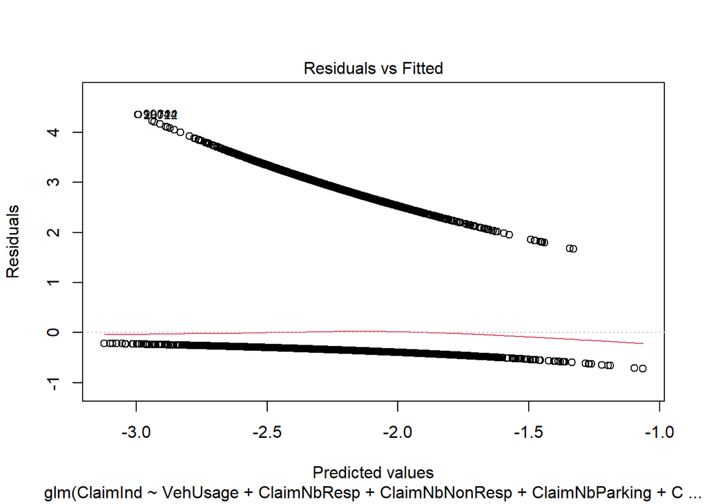

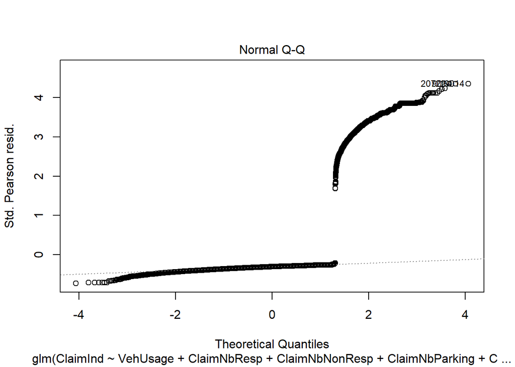

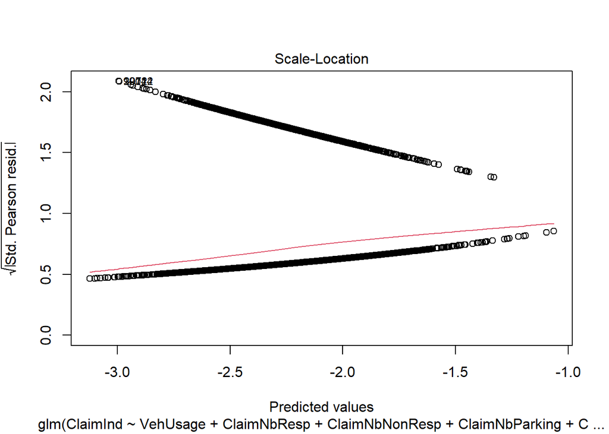

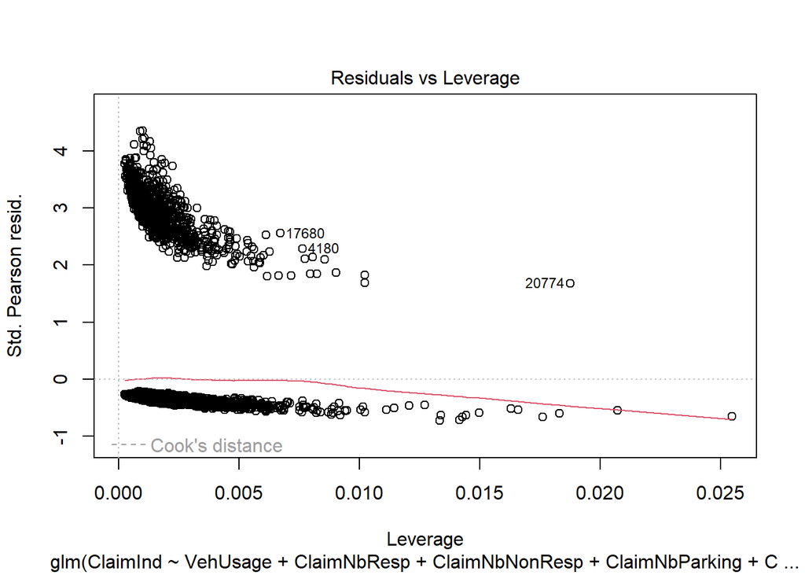

```r
plot(modBoth)
```

Test pour voir si il y a des outliers :

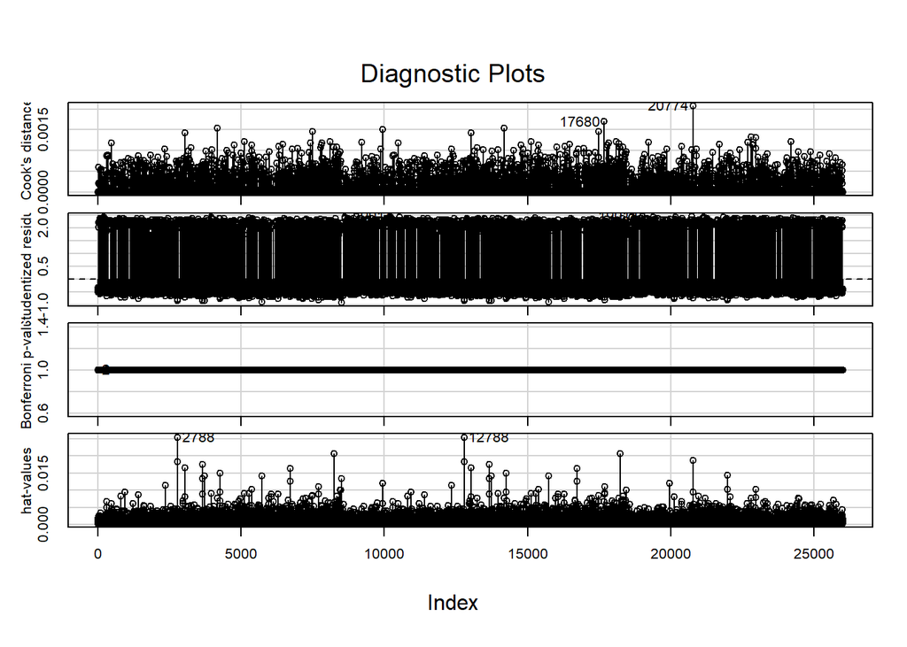

```r
influenceIndexPlot(modBoth)
```

```r
outlierTest(modBoth)
```

```
## No Studentized residuals with Bonferroni p < 0.05
## Largest |rstudent|:
##      rstudent unadjusted p-value Bonferroni p
## 9014 2.450678           0.014259           NA
```

Si p-Bonferroni >0,05 alors on conserve l’hyptohèse que ce n’est pas un outlier.

Il n’y a donc pas d’outlier ici dans ce modèle.

## Prédiction avec le modèle binomial

### Evaluation du modèle sur les données tests

```r
estimation <- modBoth$fitted.values
hist(estimation)
```

[output not shown]

### Utilisation de métriques de comparaison

#### RMSE

```r
RMSE_train <- sqrt(mean(modBoth$residuals^2))
RMSE_train
```

```
## [1] 3.192751
```

### AUC

#### Sur le jeu de données train

```r
pred=prediction(modBoth$fitted.values, train$ClaimInd)
perf=performance(pred,"tpr", "fpr")

auc_ROCR <- performance(pred, measure = "auc")
(auc_ROCR <- round(auc_ROCR@y.values[[1]],3) )
```

```
## [1] 0.593
```

#### Sur le jeu de données test

```r
prev_step <- predict(modBoth,newdata=test,type="response")
prev_prob <- data.frame(complet=predict(modFull,newdata=test, type="response"),step=predict(modBoth,newdata=test,type="response"))
head(round(prev_prob,3), n=3)
```

```
##    complet  step
## 11   0.073 0.073
## 14   0.065 0.065
## 15   0.088 0.088
```

```r
prev_class <- ifelse(prev_prob>0.2, 1, 0)
head(prev_class, n=3)
```

```
##    complet step
## 11       0    0
## 14       0    0
## 15       0    0
```

```r
mean(as.factor(prev_class[,1])==test$ClaimInd)
```

```
## [1] 0.9047997
```

```r
mean(as.factor(prev_class[,2])==test$ClaimInd)
```

```
## [1] 0.9053947
```

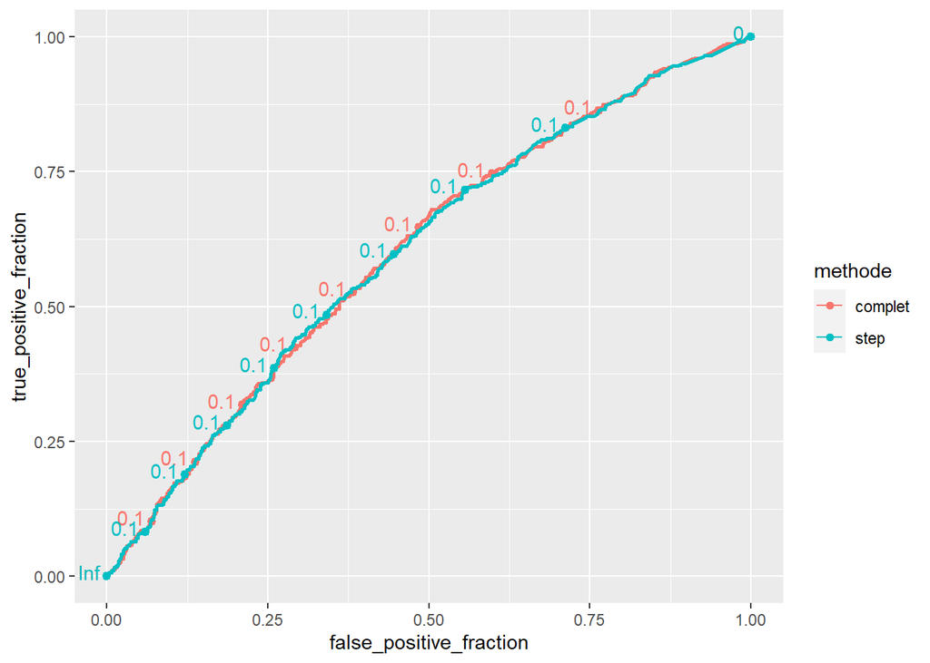

```r
df_roc <- prev_prob %>% mutate(obs=as.numeric(test$ClaimInd)) %>% gather(key=methode,value=score,complet,step)
ggplot(df_roc, aes(m=score, d=obs,color=methode))+ geom_roc()
```

### Table de confusion

#### Sur le jeu de données train

```r
estimation <- modBoth$fitted.values
hist(estimation)
```

[output not shown]

```r
score <- ifelse(predict(modBoth,train,type="response") >.1, 1, 0)
confusion.mat = table(train$ClaimInd, score)
fauxneg = confusion.mat[2,1]
fauxpos = confusion.mat[1,2]
vraisneg = confusion.mat[1,1]
vraispos = confusion.mat[2,2]
(txerr = (fauxneg+fauxpos) / (fauxneg+fauxpos+vraisneg+vraispos))
```

```
## [1] 0.3367505
```

```r
sensibilite <- vraispos / (vraispos + fauxneg)
precision <- vraispos / (vraispos + fauxpos)
specificite <- vraisneg / (vraisneg + fauxpos)

confusion.mat
```

```
##    score
##         0     1
##   0 12836  5888
##   1  1076   880
```

#### Sur le jeu de données test

```r
estimation <- modBoth$fitted.values
hist(estimation)
```

[output not shown]

```r
score <- ifelse(predict(modBoth,test,type="response") >.2, 1, 0)
confusion.mat = table(test$ClaimInd, score)
fauxneg = confusion.mat[2,1]
fauxpos = confusion.mat[1,2]
vraisneg = confusion.mat[1,1]
vraispos = confusion.mat[2,2]
(txerr = (fauxneg+fauxpos) / (fauxneg+fauxpos+vraisneg+vraispos))
```

```
## [1] 0.09460532
```

```r
sensibilite <- vraispos / (vraispos + fauxneg)
precision <- vraispos / (vraispos + fauxpos)
specificite <- vraisneg / (vraisneg + fauxpos)

confusion.mat
```

```
##    score
##        0    1
##   0 4562   18
##   1  459    3
```

## Cross Validation

```r
fit.control <- trainControl(method = "repeatedcv", number = 5, repeats = 10)

fit <- train(ClaimInd ~ MariStat+Categ+VehUsage+HasKmLimit+ClaimNbResp+ClaimNbNonResp+ClaimNbParking+ClaimNbFireTheft+ClaimNbWindscreen+OutUseNb+Risque+BonusMalus+DrivAge_fact,
    data = train, method = "glm",
    family = "binomial", trControl = fit.control)
summary(fit)
```

```
##
## Call:
## NULL
##
## Deviance Residuals:
##     Min       1Q   Median       3Q      Max
## -0.8774  -0.4695  -0.4194  -0.3818   2.4592
##
## Coefficients:
##                                  Estimate Std. Error z value Pr(>|z|)
## (Intercept)                      -2.66586    0.28835  -9.245  < 2e-16 ***
## MariStatOther                     0.02829    0.07653   0.370  0.71167
## Categ1                            0.33994    0.14007   2.427  0.01523 *
## Categ2                            0.42086    0.16096   2.615  0.00893 **
## Categ3                            0.39171    0.12663   3.093  0.00198 **
## Categ4                            0.27944    0.16321   1.712  0.08687 .
## `VehUsagePrivate+trip to office`  0.05186    0.08458   0.613  0.53979
## VehUsageProfessional              0.31400    0.10033   3.130  0.00175 **
## `VehUsageProfessional run`        0.39504    0.14868   2.657  0.00788 **
## HasKmLimit1                      -0.11905    0.10320  -1.154  0.24866
## ClaimNbResp                       0.09346    0.04713   1.983  0.04738 *
## ClaimNbNonResp                    0.15446    0.03584   4.309 1.64e-05 ***
## ClaimNbParking                    0.16863    0.07084   2.381  0.01729 *
## ClaimNbFireTheft                  0.13496    0.07578   1.781  0.07492 .
## ClaimNbWindscreen                 0.12472    0.03243   3.846  0.00012 ***
## OutUseNb                          0.03152    0.03415   0.923  0.35596
## Risque1                          -0.23686    0.12894  -1.837  0.06621 .
## Risque2                          -0.09653    0.13694  -0.705  0.48085
## Risque3                          -0.01225    0.14170  -0.086  0.93108
## Risque4                           0.20149    0.16721   1.205  0.22819
## BonusMalus                        0.00395    0.00214   1.845  0.06501 .
## `DrivAge_fact(25,30]`            -0.11641    0.15146  -0.769  0.44215
## `DrivAge_fact(30,35]`            -0.44903    0.15481  -2.900  0.00373 **
## `DrivAge_fact(35,40]`            -0.34904    0.15898  -2.195  0.02813 *
## `DrivAge_fact(40,45]`            -0.22169    0.16112  -1.376  0.16884
## `DrivAge_fact(45,50]`            -0.27830    0.16275  -1.710  0.08727 .
## `DrivAge_fact(50,58]`            -0.43582    0.15787  -2.761  0.00577 **
## `DrivAge_fact(58,65]`            -0.21025    0.16890  -1.245  0.21321
## `DrivAge_fact(65,120]`           -0.29439    0.18450  -1.596  0.11058
## ---
## Signif. codes:  0 '***' 0.001 '**' 0.01 '*' 0.05 '.' 0.1 ' ' 1
##
## (Dispersion parameter for binomial family taken to be 1)
##
##     Null deviance: 12946  on 20679  degrees of freedom
## Residual deviance: 12768  on 20651  degrees of freedom
## AIC: 12826
##
## Number of Fisher Scoring iterations: 5
```

# 2) Modélisation de `Sinistres2` (variable dans $\mathbb{N}$)

## a) Modélisation avec une Poisson

```r
summary(freMPL5$Sinistres)
```

```
##     Min.  1st Qu.   Median     Mean  3rd Qu.     Max.
##   0.0000   0.0000   0.0000   0.2707   0.0000 500.0000
```

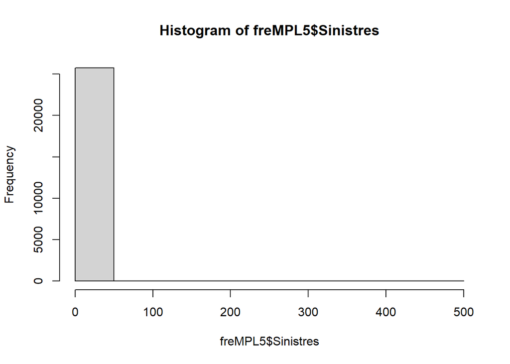

```r
bornes = seq(0,501,1)
hist(freMPL5$Sinistres)
```

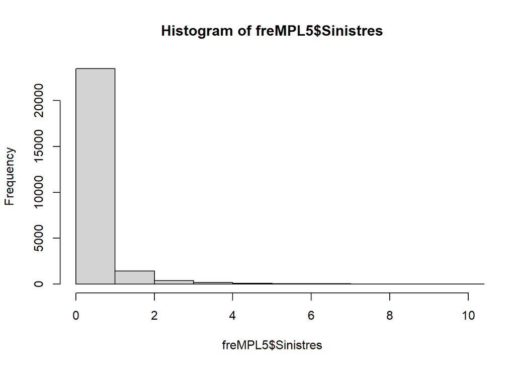

```r
hist(freMPL5$Sinistres, breaks=bornes, xlim=c(0,10))
```

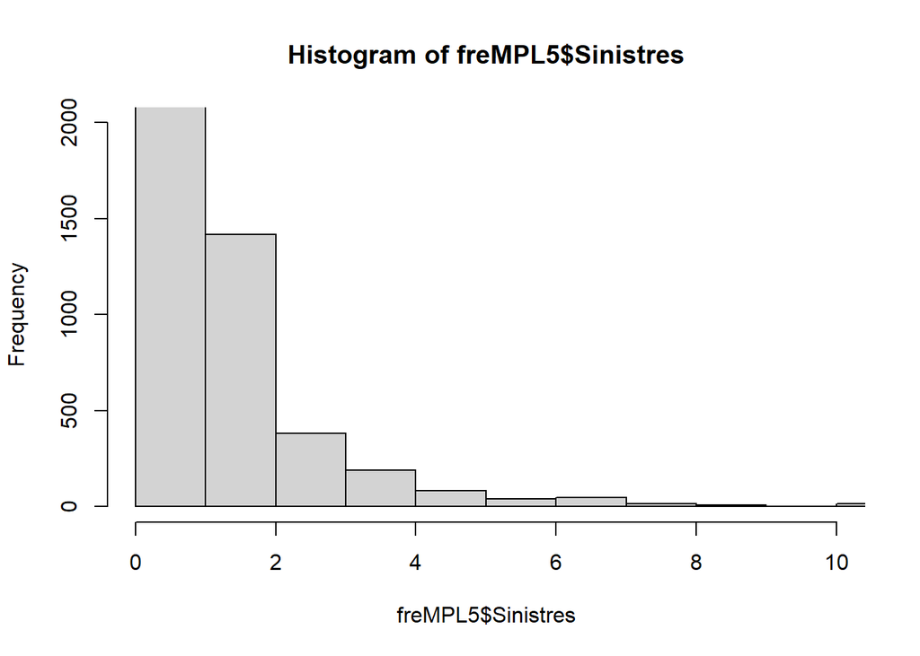

```r
hist(freMPL5$Sinistres, breaks=bornes, xlim=c(0,10), ylim = c(0,2000))
```

### Lien log (lien canonique)

```r
mod0_2 <- glm(Sinistres2 ~ 1, data = train, family = poisson(link = "log"))
summary(mod0_2)
```

```
##
## Call:
## glm(formula = Sinistres2 ~ 1, family = poisson(link = "log"),
##     data = train)
##
## Deviance Residuals:
##    Min      1Q  Median      3Q     Max
## -0.741  -0.741  -0.741  -0.741  80.667
##
## Coefficients:
##             Estimate Std. Error z value Pr(>|z|)
## (Intercept) -1.29204    0.01327  -97.39   <2e-16 ***
## ---
## Signif. codes:  0 '***' 0.001 '**' 0.01 '*' 0.05 '.' 0.1 ' ' 1
##
## (Dispersion parameter for poisson family taken to be 1)
##
##     Null deviance: 39129  on 20679  degrees of freedom
## Residual deviance: 39129  on 20679  degrees of freedom
## AIC: 44083
##
## Number of Fisher Scoring iterations: 7
```

```r
-2*as.numeric(logLik(mod0_2))
```

```
## [1] 44081.15
```

```r
modFull_2 <- glm(Sinistres2 ~ MariStat+VehUsage+HasKmLimit+ClaimNbResp+ClaimNbNonResp+ClaimNbParking+ClaimNbFireTheft+ClaimNbWindscreen+OutUseNb+BonusMalus+Risque+DrivAge_fact+Categ, data = train, family = poisson(link = "log"))
summary(modFull_2)
```

```
##
## Call:
## glm(formula = Sinistres2 ~ MariStat + VehUsage + HasKmLimit +
##     ClaimNbResp + ClaimNbNonResp + ClaimNbParking + ClaimNbFireTheft +
##     ClaimNbWindscreen + OutUseNb + BonusMalus + Risque + DrivAge_fact +
##     Categ, family = poisson(link = "log"), data = train)
##
## Deviance Residuals:
##    Min      1Q  Median      3Q     Max
## -5.053  -0.733  -0.558  -0.497  59.181
##
## Coefficients:
##                                 Estimate Std. Error z value Pr(>|z|)
## (Intercept)                    -1.498319   0.171846  -8.719  < 2e-16 ***
## MariStatOther                   0.125019   0.046136   2.710  0.00673 **
## VehUsagePrivate+trip to office  0.018720   0.050515   0.371  0.71095
## VehUsageProfessional            0.381804   0.055884   6.832 8.37e-12 ***
## VehUsageProfessional run       -0.577994   0.089021  -6.493 8.43e-11 ***
## HasKmLimit1                    -0.067605   0.065309  -1.035  0.30060
## ClaimNbResp                    -0.125556   0.028526  -4.401 1.08e-05 ***
## ClaimNbNonResp                  0.545195   0.014011  38.913  < 2e-16 ***
## ClaimNbParking                  0.023854   0.043628   0.547  0.58454
## ClaimNbFireTheft               -0.283398   0.050673  -5.593 2.24e-08 ***
## ClaimNbWindscreen               0.123882   0.017035   7.272 3.54e-13 ***
## OutUseNb                        0.020998   0.018141   1.158  0.24706
## BonusMalus                     -0.001128   0.001304  -0.866  0.38668
## Risque1                        -0.036916   0.076967  -0.480  0.63149
## Risque2                        -0.166582   0.081786  -2.037  0.04167 *
## Risque3                        -0.486878   0.087421  -5.569 2.56e-08 ***
## Risque4                        -0.305338   0.106975  -2.854  0.00431 **
## DrivAge_fact(25,30]            -0.159518   0.082357  -1.937  0.05276 .
## DrivAge_fact(30,35]            -0.838306   0.088515  -9.471  < 2e-16 ***
## DrivAge_fact(35,40]            -0.858537   0.091466  -9.386  < 2e-16 ***
## DrivAge_fact(40,45]            -0.769939   0.091724  -8.394  < 2e-16 ***
## DrivAge_fact(45,50]             0.120021   0.086812   1.383  0.16681
## DrivAge_fact(50,58]            -0.948353   0.089557 -10.589  < 2e-16 ***
## DrivAge_fact(58,65]            -0.935217   0.097798  -9.563  < 2e-16 ***
## DrivAge_fact(65,120]           -0.988648   0.107498  -9.197  < 2e-16 ***
## Categ1                          1.474002   0.080464  18.319  < 2e-16 ***
## Categ2                          0.127988   0.101943   1.255  0.20930
## Categ3                          0.412835   0.078985   5.227 1.73e-07 ***
## Categ4                          0.518937   0.102913   5.042 4.60e-07 ***
## ---
## Signif. codes:  0 '***' 0.001 '**' 0.01 '*' 0.05 '.' 0.1 ' ' 1
##
## (Dispersion parameter for poisson family taken to be 1)
##
##     Null deviance: 39129  on 20679  degrees of freedom
## Residual deviance: 34831  on 20651  degrees of freedom
## AIC: 39841
##
## Number of Fisher Scoring iterations: 8
```

```r
modBoth_2 = step(modFull_2, mod0_2, trace=F, direction = c('both'))
summary(modBoth_2)
```

```
##
## Call:
## glm(formula = Sinistres2 ~ MariStat + VehUsage + ClaimNbResp +
##     ClaimNbNonResp + ClaimNbFireTheft + ClaimNbWindscreen + Risque +
##     DrivAge_fact + Categ, family = poisson(link = "log"), data = train)
##
## Deviance Residuals:
##    Min      1Q  Median      3Q     Max
## -4.882  -0.734  -0.555  -0.500  59.086
##
## Coefficients:
##                                Estimate Std. Error z value Pr(>|z|)
## (Intercept)                    -1.59136    0.13065 -12.180  < 2e-16 ***
## MariStatOther                   0.12966    0.04599   2.819  0.00482 **
## VehUsagePrivate+trip to office  0.02341    0.05035   0.465  0.64192
## VehUsageProfessional            0.39187    0.05551   7.059 1.68e-12 ***
## VehUsageProfessional run       -0.56602    0.08866  -6.384 1.72e-10 ***
## ClaimNbResp                    -0.13437    0.02577  -5.214 1.85e-07 ***
## ClaimNbNonResp                  0.54684    0.01396  39.163  < 2e-16 ***
## ClaimNbFireTheft               -0.28402    0.05064  -5.609 2.04e-08 ***
## ClaimNbWindscreen               0.12502    0.01699   7.357 1.88e-13 ***
## Risque1                        -0.04072    0.07689  -0.530  0.59635
## Risque2                        -0.17003    0.08172  -2.081  0.03746 *
## Risque3                        -0.49286    0.08720  -5.652 1.59e-08 ***
## Risque4                        -0.29740    0.10681  -2.785  0.00536 **
## DrivAge_fact(25,30]            -0.15083    0.08172  -1.846  0.06495 .
## DrivAge_fact(30,35]            -0.81958    0.08492  -9.651  < 2e-16 ***
## DrivAge_fact(35,40]            -0.83095    0.08535  -9.736  < 2e-16 ***
## DrivAge_fact(40,45]            -0.74112    0.08356  -8.869  < 2e-16 ***
## DrivAge_fact(45,50]             0.15114    0.07664   1.972  0.04859 *
## DrivAge_fact(50,58]            -0.91733    0.07898 -11.615  < 2e-16 ***
## DrivAge_fact(58,65]            -0.90497    0.08880 -10.191  < 2e-16 ***
## DrivAge_fact(65,120]           -0.96141    0.09916  -9.695  < 2e-16 ***
## Categ1                          1.47549    0.08041  18.349  < 2e-16 ***
## Categ2                          0.12891    0.10193   1.265  0.20601
## Categ3                          0.41256    0.07897   5.225 1.75e-07 ***
## Categ4                          0.51890    0.10290   5.042 4.60e-07 ***
## ---
## Signif. codes:  0 '***' 0.001 '**' 0.01 '*' 0.05 '.' 0.1 ' ' 1
##
## (Dispersion parameter for poisson family taken to be 1)
##
##     Null deviance: 39129  on 20679  degrees of freedom
## Residual deviance: 34835  on 20655  degrees of freedom
## AIC: 39837
##
## Number of Fisher Scoring iterations: 8
```

Cependant, continuons avant cela d’explorer les modèles. Ensuite nous en sélectionnerons un et nous l’améliorerons.

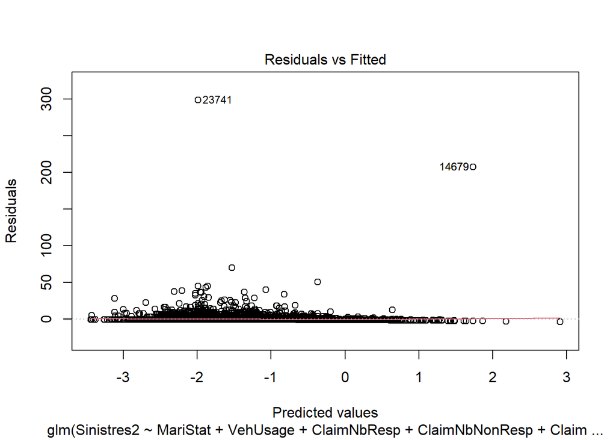

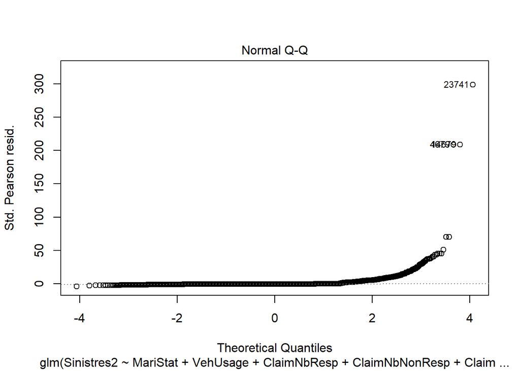

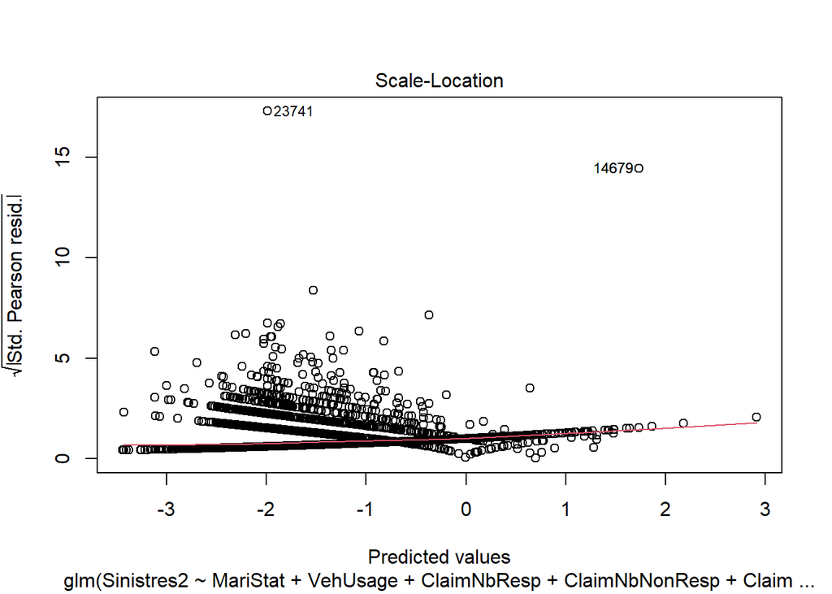

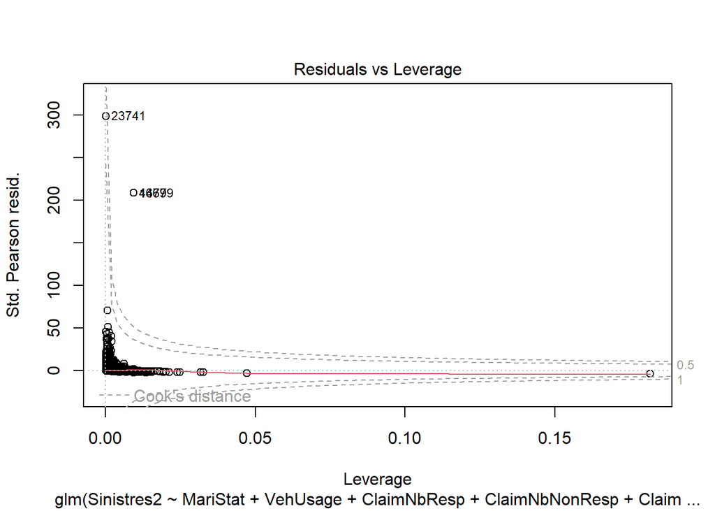

```r
plot(modBoth_2)
```

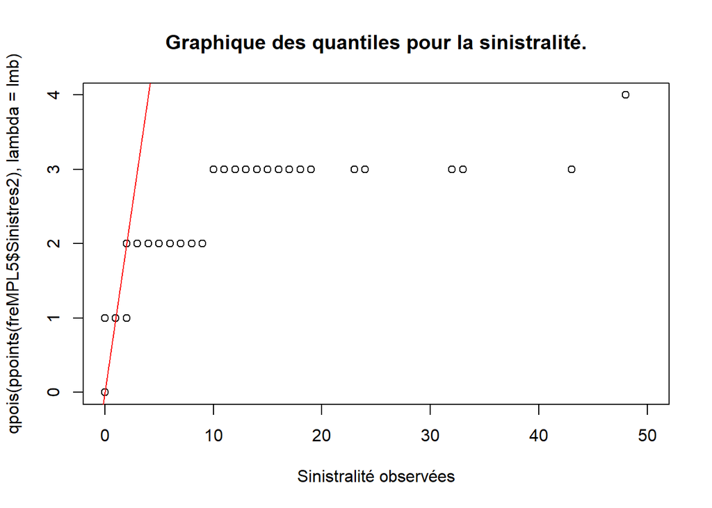

```r
lmb = mean(freMPL5$Sinistres2)
qqplot (freMPL5$Sinistres2, qpois(ppoints(freMPL5$Sinistres2), lambda = lmb),
            xlab ="Sinistralité observées",
        main ="Graphique des quantiles pour la sinistralité.", xlim = c(0,50))
abline (a=0,b=1, col ="red")
```

Remarque : Nous avons tronquer xlim afin d’avoir une interprétation possible et visuelle. Sinon, il y avait quelques éléments qui allait bien trop loin (valeurs trop extrèmes).

Avec ce graphique des qqplot. On remarque bien que la loi de Poisson n’est pas adaptée à cette modélisation. En effet, il y a quelques observations qui sont très élevés, qui faussent la moyenne (appelée lmb ici qui est aussi le paramètre de la loi). Alors nous allons tenter de modéliser en enlevant dans un premier temps les données qui dépassent un certain seuil.

```r
RMSE_2_train <- sqrt(mean(modBoth_2$residuals^2))
RMSE_2_train
```

```
## [1] 8.093153
```

### Lien identité

```r
mod0_identité <- glm(Sinistres2 ~ 1, data = train, family = poisson(link = "identity"))
summary(mod0_identité)
```

```
##
## Call:
## glm(formula = Sinistres2 ~ 1, family = poisson(link = "identity"),
##     data = train)
##
## Deviance Residuals:
##    Min      1Q  Median      3Q     Max
## -0.741  -0.741  -0.741  -0.741  80.667
##
## Coefficients:
##             Estimate Std. Error z value Pr(>|z|)
## (Intercept) 0.274710   0.003645   75.37   <2e-16 ***
## ---
## Signif. codes:  0 '***' 0.001 '**' 0.01 '*' 0.05 '.' 0.1 ' ' 1
##
## (Dispersion parameter for poisson family taken to be 1)
##
##     Null deviance: 39129  on 20679  degrees of freedom
## Residual deviance: 39129  on 20679  degrees of freedom
## AIC: 44083
##
## Number of Fisher Scoring iterations: 3
```

```r
#modFull_identité <- glm(Sinistres2 ~ MariStat+Categ+VehUsage+HasKmLimit+ClaimNbResp+ClaimNbNonResp+ClaimNbParking+ClaimNbFireTheft+ClaimNbWindscreen+OutUseNb+RiskArea+BonusMalus+DrivAge_fact, data = train, family = poisson(link = "identity"))
#summary(modFull_identité)
```

Il y a une erreur. Est-ce par rapport au fait qu’il ne pervient pas à trouver des valeurs pour les coefficients et donc que la méthode n’est pas convergente ?

### Lien sqrt

Remarque : d’après la documentation R, on ne pourra pas utiliser d’autres liens car “the `poisson` family accepts the links `log`, `identity`, and `sqrt`”.

```r
mod0_sqrt <- glm(Sinistres2 ~ 1, data = train, family = poisson(link = "sqrt"))
summary(mod0_sqrt)
```

```
##
## Call:
## glm(formula = Sinistres2 ~ 1, family = poisson(link = "sqrt"),
##     data = train)
##
## Deviance Residuals:
##    Min      1Q  Median      3Q     Max
## -0.741  -0.741  -0.741  -0.741  80.667
##
## Coefficients:
##             Estimate Std. Error z value Pr(>|z|)
## (Intercept) 0.524128   0.003477   150.7   <2e-16 ***
## ---
## Signif. codes:  0 '***' 0.001 '**' 0.01 '*' 0.05 '.' 0.1 ' ' 1
##
## (Dispersion parameter for poisson family taken to be 1)
##
##     Null deviance: 39129  on 20679  degrees of freedom
## Residual deviance: 39129  on 20679  degrees of freedom
## AIC: 44083
##
## Number of Fisher Scoring iterations: 6
```

```r
modFull_sqrt <- glm(Sinistres2 ~ MariStat+Categ+VehUsage+HasKmLimit+ClaimNbResp+ClaimNbNonResp+ClaimNbParking+ClaimNbFireTheft+ClaimNbWindscreen+OutUseNb+Risque+BonusMalus+DrivAge_fact, data = train, family = poisson(link = "sqrt"))
summary(modFull_sqrt)
```

```
##
## Call:
## glm(formula = Sinistres2 ~ MariStat + Categ + VehUsage + HasKmLimit +
##     ClaimNbResp + ClaimNbNonResp + ClaimNbParking + ClaimNbFireTheft +
##     ClaimNbWindscreen + OutUseNb + Risque + BonusMalus + DrivAge_fact,
##     family = poisson(link = "sqrt"), data = train)
##
## Deviance Residuals:
##    Min      1Q  Median      3Q     Max
## -2.043  -0.799  -0.606  -0.517  69.349
##
## Coefficients:
##                                  Estimate Std. Error z value Pr(>|z|)
## (Intercept)                     0.4937484  0.0440937  11.198  < 2e-16 ***
## MariStatOther                   0.0453896  0.0113123   4.012 6.01e-05 ***
## Categ1                          0.3399584  0.0200369  16.967  < 2e-16 ***
## Categ2                          0.0303137  0.0236673   1.281 0.200256
## Categ3                          0.0809638  0.0173571   4.665 3.09e-06 ***
## Categ4                          0.0789864  0.0222333   3.553 0.000381 ***
## VehUsagePrivate+trip to office  0.0265999  0.0119812   2.220 0.026409 *
## VehUsageProfessional            0.1104087  0.0148264   7.447 9.57e-14 ***
## VehUsageProfessional run       -0.0696165  0.0230789  -3.016 0.002557 **
## HasKmLimit1                    -0.0032932  0.0135938  -0.242 0.808584
## ClaimNbResp                    -0.0051618  0.0072508  -0.712 0.476530
## ClaimNbNonResp                  0.1432207  0.0058003  24.692  < 2e-16 ***
## ClaimNbParking                  0.0286566  0.0113371   2.528 0.011482 *
## ClaimNbFireTheft               -0.0390729  0.0119834  -3.261 0.001112 **
## ClaimNbWindscreen               0.0238127  0.0051017   4.668 3.05e-06 ***
## OutUseNb                        0.0232673  0.0053733   4.330 1.49e-05 ***
## Risque1                        -0.0437291  0.0194821  -2.245 0.024795 *
## Risque2                        -0.0292782  0.0207263  -1.413 0.157771
## Risque3                        -0.0827314  0.0216447  -3.822 0.000132 ***
## Risque4                        -0.0491690  0.0266667  -1.844 0.065208 .
## BonusMalus                     -0.0001697  0.0003382  -0.502 0.615880
## DrivAge_fact(25,30]            -0.0326530  0.0250360  -1.304 0.192150
## DrivAge_fact(30,35]            -0.1883928  0.0246482  -7.643 2.12e-14 ***
## DrivAge_fact(35,40]            -0.1773709  0.0255618  -6.939 3.95e-12 ***
## DrivAge_fact(40,45]            -0.1727818  0.0260377  -6.636 3.23e-11 ***
## DrivAge_fact(45,50]            -0.0210098  0.0261693  -0.803 0.422066
## DrivAge_fact(50,58]            -0.2091201  0.0253339  -8.255  < 2e-16 ***
## DrivAge_fact(58,65]            -0.1992269  0.0271025  -7.351 1.97e-13 ***
## DrivAge_fact(65,120]           -0.2148243  0.0288035  -7.458 8.77e-14 ***
## ---
## Signif. codes:  0 '***' 0.001 '**' 0.01 '*' 0.05 '.' 0.1 ' ' 1
##
## (Dispersion parameter for poisson family taken to be 1)
##
##     Null deviance: 39129  on 20679  degrees of freedom
## Residual deviance: 36188  on 20651  degrees of freedom
## AIC: 41198
##
## Number of Fisher Scoring iterations: 11
```

```r
modBoth_sqrt = step(modFull_sqrt, mod0_sqrt, trace = F, direction = c("both"))
```

[output not shown]

[output cut: 40 more lines]

[output not shown]

```r
summary(modBoth_sqrt)
```

```
##
## Call:
## glm(formula = Sinistres2 ~ MariStat + Categ + VehUsage + ClaimNbNonResp +
##     ClaimNbParking + ClaimNbFireTheft + ClaimNbWindscreen + OutUseNb +
##     Risque + DrivAge_fact, family = poisson(link = "sqrt"), data = train)
##
## Deviance Residuals:
##    Min      1Q  Median      3Q     Max
## -2.039  -0.798  -0.604  -0.516  69.370
##
## Coefficients:
##                                 Estimate Std. Error z value Pr(>|z|)
## (Intercept)                     0.477263   0.032565  14.656  < 2e-16 ***
## MariStatOther                   0.046202   0.011261   4.103 4.08e-05 ***
## Categ1                          0.339762   0.020033  16.960  < 2e-16 ***
## Categ2                          0.029613   0.023665   1.251 0.210805
## Categ3                          0.080563   0.017355   4.642 3.45e-06 ***
## Categ4                          0.079460   0.022229   3.575 0.000351 ***
## VehUsagePrivate+trip to office  0.026863   0.011940   2.250 0.024454 *
## VehUsageProfessional            0.110034   0.014730   7.470 8.00e-14 ***
## VehUsageProfessional run       -0.069433   0.022987  -3.021 0.002523 **
## ClaimNbNonResp                  0.143078   0.005789  24.718  < 2e-16 ***
## ClaimNbParking                  0.028675   0.011326   2.532 0.011347 *
## ClaimNbFireTheft               -0.039047   0.011982  -3.259 0.001119 **
## ClaimNbWindscreen               0.024049   0.005091   4.724 2.32e-06 ***
## OutUseNb                        0.022963   0.005359   4.285 1.83e-05 ***
## Risque1                        -0.043670   0.019469  -2.243 0.024894 *
## Risque2                        -0.029370   0.020706  -1.418 0.156067
## Risque3                        -0.083777   0.021608  -3.877 0.000106 ***
## Risque4                        -0.048848   0.026645  -1.833 0.066760 .
## DrivAge_fact(25,30]            -0.030784   0.024826  -1.240 0.214980
## DrivAge_fact(30,35]            -0.185002   0.023745  -7.791 6.63e-15 ***
## DrivAge_fact(35,40]            -0.172551   0.023963  -7.201 5.99e-13 ***
## DrivAge_fact(40,45]            -0.168597   0.023912  -7.051 1.78e-12 ***
## DrivAge_fact(45,50]            -0.015088   0.023754  -0.635 0.525319
## DrivAge_fact(50,58]            -0.203256   0.022665  -8.968  < 2e-16 ***
## DrivAge_fact(58,65]            -0.194454   0.024695  -7.874 3.43e-15 ***
## DrivAge_fact(65,120]           -0.210673   0.026469  -7.959 1.73e-15 ***
## ---
## Signif. codes:  0 '***' 0.001 '**' 0.01 '*' 0.05 '.' 0.1 ' ' 1
##
## (Dispersion parameter for poisson family taken to be 1)
##
##     Null deviance: 39129  on 20679  degrees of freedom
## Residual deviance: 36190  on 20654  degrees of freedom
## AIC: 41194
##
## Number of Fisher Scoring iterations: 11
```

## b) Modélisation avec une Binomiale Négative

Utiliser `glm.nb`.

```r
modBN_0 <- glm.nb(Sinistres2 ~ 1, data = train)
summary(modBN_0)
```

```
##
## Call:
## glm.nb(formula = Sinistres2 ~ 1, data = train, init.theta = 0.05503619748,
##     link = log)
##
## Deviance Residuals:
##     Min       1Q   Median       3Q      Max
## -0.4439  -0.4439  -0.4439  -0.4439  13.4793
##
## Coefficients:
##             Estimate Std. Error z value Pr(>|z|)
## (Intercept) -1.29204    0.03248  -39.78   <2e-16 ***
## ---
## Signif. codes:  0 '***' 0.001 '**' 0.01 '*' 0.05 '.' 0.1 ' ' 1
##
## (Dispersion parameter for Negative Binomial(0.055) family taken to be 1)
##
##     Null deviance: 5180.4  on 20679  degrees of freedom
## Residual deviance: 5180.4  on 20679  degrees of freedom
## AIC: 19624
##
## Number of Fisher Scoring iterations: 1
##
##
##               Theta:  0.05504
##           Std. Err.:  0.00173
##
##  2 x log-likelihood:  -19620.45000
```

```r
-2*as.numeric(logLik(modBN_0))
```

```
## [1] 19620.45
```

```r
modBN_Full <- glm.nb(Sinistres2 ~ MariStat+Categ+VehUsage+HasKmLimit+ClaimNbResp+ClaimNbNonResp+ClaimNbParking+ClaimNbFireTheft+ClaimNbWindscreen+OutUseNb+Risque+BonusMalus+DrivAge_fact, data = train)
summary(modBN_Full)
```

```
##
## Call:
## glm.nb(formula = Sinistres2 ~ MariStat + Categ + VehUsage + HasKmLimit +
##     ClaimNbResp + ClaimNbNonResp + ClaimNbParking + ClaimNbFireTheft +
##     ClaimNbWindscreen + OutUseNb + Risque + BonusMalus + DrivAge_fact,
##     data = train, init.theta = 0.065162647, link = log)
##
## Deviance Residuals:
##     Min       1Q   Median       3Q      Max
## -0.7127  -0.4674  -0.4242  -0.3894   8.5625
##
## Coefficients:
##                                  Estimate Std. Error z value Pr(>|z|)
## (Intercept)                    -1.584e+00  3.901e-01  -4.060 4.91e-05 ***
## MariStatOther                   2.079e-01  1.017e-01   2.044 0.040981 *
## Categ1                          9.502e-01  1.788e-01   5.315 1.07e-07 ***
## Categ2                          3.031e-01  2.123e-01   1.428 0.153421
## Categ3                          3.803e-01  1.589e-01   2.393 0.016698 *
## Categ4                          2.900e-01  2.051e-01   1.414 0.157377
## VehUsagePrivate+trip to office  1.629e-01  1.082e-01   1.505 0.132267
## VehUsageProfessional            3.823e-01  1.318e-01   2.900 0.003732 **
## VehUsageProfessional run        2.702e-02  2.038e-01   0.133 0.894493
## HasKmLimit1                    -2.697e-02  1.254e-01  -0.215 0.829685
## ClaimNbResp                     3.472e-02  6.437e-02   0.539 0.589653
## ClaimNbNonResp                  4.329e-01  4.926e-02   8.788  < 2e-16 ***
## ClaimNbParking                  1.635e-01  9.930e-02   1.646 0.099728 .
## ClaimNbFireTheft               -1.178e-01  1.080e-01  -1.091 0.275461
## ClaimNbWindscreen               8.398e-02  4.481e-02   1.874 0.060931 .
## OutUseNb                        1.075e-01  4.613e-02   2.330 0.019824 *
## Risque1                        -2.183e-01  1.732e-01  -1.260 0.207606
## Risque2                        -9.210e-02  1.840e-01  -0.500 0.616729
## Risque3                        -2.808e-01  1.928e-01  -1.456 0.145409
## Risque4                        -1.562e-01  2.369e-01  -0.659 0.509796
## BonusMalus                     -8.758e-05  2.983e-03  -0.029 0.976575
## DrivAge_fact(25,30]            -1.236e-01  2.140e-01  -0.577 0.563701
## DrivAge_fact(30,35]            -6.766e-01  2.137e-01  -3.166 0.001544 **
## DrivAge_fact(35,40]            -6.288e-01  2.214e-01  -2.840 0.004517 **
## DrivAge_fact(40,45]            -6.119e-01  2.256e-01  -2.713 0.006676 **
## DrivAge_fact(45,50]            -3.835e-01  2.259e-01  -1.698 0.089526 .
## DrivAge_fact(50,58]            -7.523e-01  2.196e-01  -3.426 0.000613 ***
## DrivAge_fact(58,65]            -7.005e-01  2.359e-01  -2.969 0.002983 **
## DrivAge_fact(65,120]           -7.641e-01  2.529e-01  -3.022 0.002512 **
## ---
## Signif. codes:  0 '***' 0.001 '**' 0.01 '*' 0.05 '.' 0.1 ' ' 1
##
## (Dispersion parameter for Negative Binomial(0.0652) family taken to be 1)
##
##     Null deviance: 5764.1  on 20679  degrees of freedom
## Residual deviance: 5352.8  on 20651  degrees of freedom
## AIC: 19298
##
## Number of Fisher Scoring iterations: 1
##
##
##               Theta:  0.06516
##           Std. Err.:  0.00214
## Warning while fitting theta: limite d'alternation atteinte
##
##  2 x log-likelihood:  -19238.33800
```

## c) Modélisation avec une Quasi-Poisson

```r
mod0_3 <- glm(Sinistres2 ~ 1, data = train, family = quasipoisson(link = "log"))
summary(mod0_3)
```

```
##
## Call:
## glm(formula = Sinistres2 ~ 1, family = quasipoisson(link = "log"),
##     data = train)
##
## Deviance Residuals:
##    Min      1Q  Median      3Q     Max
## -0.741  -0.741  -0.741  -0.741  80.667
##
## Coefficients:
##             Estimate Std. Error t value Pr(>|t|)
## (Intercept)  -1.2920     0.1289  -10.03   <2e-16 ***
## ---
## Signif. codes:  0 '***' 0.001 '**' 0.01 '*' 0.05 '.' 0.1 ' ' 1
##
## (Dispersion parameter for quasipoisson family taken to be 94.33083)
##
##     Null deviance: 39129  on 20679  degrees of freedom
## Residual deviance: 39129  on 20679  degrees of freedom
## AIC: NA
##
## Number of Fisher Scoring iterations: 7
```

```r
modFull_3 <- glm(Sinistres2 ~ MariStat+Categ+VehUsage+HasKmLimit+ClaimNbResp+ClaimNbNonResp+ClaimNbParking+ClaimNbFireTheft+ClaimNbWindscreen+OutUseNb+Risque+BonusMalus+DrivAge_fact, data = train, family = quasipoisson(link = "log"))
summary(modFull_3)
```

```
##
## Call:
## glm(formula = Sinistres2 ~ MariStat + Categ + VehUsage + HasKmLimit +
##     ClaimNbResp + ClaimNbNonResp + ClaimNbParking + ClaimNbFireTheft +
##     ClaimNbWindscreen + OutUseNb + Risque + BonusMalus + DrivAge_fact,
##     family = quasipoisson(link = "log"), data = train)
##
## Deviance Residuals:
##    Min      1Q  Median      3Q     Max
## -5.053  -0.733  -0.558  -0.497  59.181
##
## Coefficients:
##                                 Estimate Std. Error t value Pr(>|t|)
## (Intercept)                    -1.498319   0.641523  -2.336  0.01952 *
## MariStatOther                   0.125019   0.172231   0.726  0.46792
## Categ1                          1.474002   0.300381   4.907 9.31e-07 ***
## Categ2                          0.127988   0.380566   0.336  0.73664
## Categ3                          0.412835   0.294863   1.400  0.16150
## Categ4                          0.518937   0.384188   1.351  0.17679
## VehUsagePrivate+trip to office  0.018720   0.188578   0.099  0.92093
## VehUsageProfessional            0.381804   0.208622   1.830  0.06725 .
## VehUsageProfessional run       -0.577994   0.332329  -1.739  0.08201 .
## HasKmLimit1                    -0.067605   0.243807  -0.277  0.78156
## ClaimNbResp                    -0.125556   0.106490  -1.179  0.23840
## ClaimNbNonResp                  0.545195   0.052304  10.424  < 2e-16 ***
## ClaimNbParking                  0.023854   0.162867   0.146  0.88356
## ClaimNbFireTheft               -0.283398   0.189169  -1.498  0.13412
## ClaimNbWindscreen               0.123882   0.063594   1.948  0.05143 .
## OutUseNb                        0.020998   0.067721   0.310  0.75651
## Risque1                        -0.036916   0.287328  -0.128  0.89777
## Risque2                        -0.166582   0.305317  -0.546  0.58534
## Risque3                        -0.486878   0.326353  -1.492  0.13575
## Risque4                        -0.305338   0.399352  -0.765  0.44453
## BonusMalus                     -0.001128   0.004866  -0.232  0.81663
## DrivAge_fact(25,30]            -0.159518   0.307450  -0.519  0.60388
## DrivAge_fact(30,35]            -0.838306   0.330437  -2.537  0.01119 *
## DrivAge_fact(35,40]            -0.858537   0.341455  -2.514  0.01193 *
## DrivAge_fact(40,45]            -0.769939   0.342416  -2.249  0.02455 *
## DrivAge_fact(45,50]             0.120021   0.324082   0.370  0.71113
## DrivAge_fact(50,58]            -0.948353   0.334328  -2.837  0.00456 **
## DrivAge_fact(58,65]            -0.935217   0.365093  -2.562  0.01043 *
## DrivAge_fact(65,120]           -0.988648   0.401306  -2.464  0.01376 *
## ---
## Signif. codes:  0 '***' 0.001 '**' 0.01 '*' 0.05 '.' 0.1 ' ' 1
##
## (Dispersion parameter for quasipoisson family taken to be 13.93627)
##
##     Null deviance: 39129  on 20679  degrees of freedom
## Residual deviance: 34831  on 20651  degrees of freedom
## AIC: NA
##
## Number of Fisher Scoring iterations: 8
```

Ici, l’AIC n’étant pas défini, on ne peut pas utiliser une méthode Both, Backward ou Forward classique avec ce critère.

```r
RMSE_3_train <- sqrt(mean(modFull_3$residuals^2))
RMSE_3_train
```

```
## [1] 8.076435
```

# 3) Choix final de la modélisation et amélioration du modèle

En comparant les modèles vides avec les modèles pleins, on remarque que c’est le modèle de Poisson qui améliore le plus le critère de l’AIC. Nous allons donc choisir ce modèle. Nous sommes conscients que ce modèle ne fit pas complètement aux données et c’est pour cela que nous allons essayer de l’améliorer en cherchant des interactions cohérentes ou en utilisant uniquement certaines données.

## a) Interactions

Comme dit précédemment, la variable `Gender` qui donne le genre de l’assuré ne peut être utilisée explicitement dans le calcul de la prime d’un assuré en France. Nous décidons donc de ne pas en tenir compte dans ce mémoire même si l’information pourrait être utile.

Cherchons quelques intéractions cohérentes qui permettraient d’améliorer le modèle et comparons les avec le modèle plein classique. Notons que nous ne pourrons pas garder toutes les intéractions. En effet, si nous faisions cela, nous ferions de l’overfitting car alors certaines données seraient en trop petit nombre dans certaines catégories croisées, ce qui rendrait le modèle très dépendant de l’échantillon

Pour rappel, voici le modèle normal que nous allons nommer différemment.

```r
mod <- glm(Sinistres2 ~ ClaimNbResp+ClaimNbNonResp+ClaimNbParking+ClaimNbFireTheft+ClaimNbWindscreen+OutUseNb+BonusMalus+DrivAge_fact+Risque+MariStat+HasKmLimit+Categ+VehUsage, data = train, family = poisson(link = "log"))
summary(mod)
```

```
##
## Call:
## glm(formula = Sinistres2 ~ ClaimNbResp + ClaimNbNonResp + ClaimNbParking +
##     ClaimNbFireTheft + ClaimNbWindscreen + OutUseNb + BonusMalus +
##     DrivAge_fact + Risque + MariStat + HasKmLimit + Categ + VehUsage,
##     family = poisson(link = "log"), data = train)
##
## Deviance Residuals:
##    Min      1Q  Median      3Q     Max
## -5.053  -0.733  -0.558  -0.497  59.181
##
## Coefficients:
##                                 Estimate Std. Error z value Pr(>|z|)
## (Intercept)                    -1.498319   0.171846  -8.719  < 2e-16 ***
## ClaimNbResp                    -0.125556   0.028526  -4.401 1.08e-05 ***
## ClaimNbNonResp                  0.545195   0.014011  38.913  < 2e-16 ***
## ClaimNbParking                  0.023854   0.043628   0.547  0.58454
## ClaimNbFireTheft               -0.283398   0.050673  -5.593 2.24e-08 ***
## ClaimNbWindscreen               0.123882   0.017035   7.272 3.54e-13 ***
## OutUseNb                        0.020998   0.018141   1.158  0.24706
## BonusMalus                     -0.001128   0.001304  -0.866  0.38668
## DrivAge_fact(25,30]            -0.159518   0.082357  -1.937  0.05276 .
## DrivAge_fact(30,35]            -0.838306   0.088515  -9.471  < 2e-16 ***
## DrivAge_fact(35,40]            -0.858537   0.091466  -9.386  < 2e-16 ***
## DrivAge_fact(40,45]            -0.769939   0.091724  -8.394  < 2e-16 ***
## DrivAge_fact(45,50]             0.120021   0.086812   1.383  0.16681
## DrivAge_fact(50,58]            -0.948353   0.089557 -10.589  < 2e-16 ***
## DrivAge_fact(58,65]            -0.935217   0.097798  -9.563  < 2e-16 ***
## DrivAge_fact(65,120]           -0.988648   0.107498  -9.197  < 2e-16 ***
## Risque1                        -0.036916   0.076967  -0.480  0.63149
## Risque2                        -0.166582   0.081786  -2.037  0.04167 *
## Risque3                        -0.486878   0.087421  -5.569 2.56e-08 ***
## Risque4                        -0.305338   0.106975  -2.854  0.00431 **
## MariStatOther                   0.125019   0.046136   2.710  0.00673 **
## HasKmLimit1                    -0.067605   0.065309  -1.035  0.30060
## Categ1                          1.474002   0.080464  18.319  < 2e-16 ***
## Categ2                          0.127988   0.101943   1.255  0.20930
## Categ3                          0.412835   0.078985   5.227 1.73e-07 ***
## Categ4                          0.518937   0.102913   5.042 4.60e-07 ***
## VehUsagePrivate+trip to office  0.018720   0.050515   0.371  0.71095
## VehUsageProfessional            0.381804   0.055884   6.832 8.37e-12 ***
## VehUsageProfessional run       -0.577994   0.089021  -6.493 8.43e-11 ***
## ---
## Signif. codes:  0 '***' 0.001 '**' 0.01 '*' 0.05 '.' 0.1 ' ' 1
##
## (Dispersion parameter for poisson family taken to be 1)
##
##     Null deviance: 39129  on 20679  degrees of freedom
## Residual deviance: 34831  on 20651  degrees of freedom
## AIC: 39841
##
## Number of Fisher Scoring iterations: 8
```

Après avoir fait plusieurs interactions (tout en gardant un nombre interprétable de variables finales), nous remarquons que certaines interactions permettent d’améliorer le critère de l’AIC :

- `Categ2:MariStatOther` et `Categ3:MariStatOther`
- `Risque1:DrivAge_fact(45,50]` mais représente que 53 données donc c’est trop peu pour éviter le sur-apprentissage.
- `Risque1:DrivAge_fact(35,40]` et `Risque2:DrivAge_fact(35,40]` et `Risque3:DrivAge_fact(35,40]` et `Risque4:DrivAge_fact(35,40]`
- `Categ1 * DrivAge_fact` et `Categ3 * DrivAge_fact`
- `Categ1:VehUsageProfessional` et `Categ3:VehUsageProfessional run`

  On peut noter que l’interaction `Risque*Categ` permet d’obtenir quelques autres variables significatives mais les variables de base perdent alors en significativité. Nous ne conserverons donc pas cette interactions.

```r
mod_vide_poisson <- glm(Sinistres2 ~ 1, data = train, family = poisson(link="log"))
```

```r
mod_inter <- glm(Sinistres2 ~ ClaimNbResp+ClaimNbNonResp+ClaimNbParking+ClaimNbFireTheft+ClaimNbWindscreen+OutUseNb+BonusMalus+DrivAge_fact+Categ+Risque*MariStat+HasKmLimit+VehUsage+Categ:MariStat+Categ:DrivAge_fact, data = train, family = poisson(link = "log"))
summary(mod_inter)
```

```
##
## Call:
## glm(formula = Sinistres2 ~ ClaimNbResp + ClaimNbNonResp + ClaimNbParking +
##     ClaimNbFireTheft + ClaimNbWindscreen + OutUseNb + BonusMalus +
##     DrivAge_fact + Categ + Risque * MariStat + HasKmLimit + VehUsage +
##     Categ:MariStat + Categ:DrivAge_fact, family = poisson(link = "log"),
##     data = train)
##
## Deviance Residuals:
##    Min      1Q  Median      3Q     Max
## -5.467  -0.703  -0.575  -0.493  51.457
##
## Coefficients: (4 not defined because of singularities)
##                                  Estimate Std. Error z value Pr(>|z|)
## (Intercept)                     -3.094749   0.464520  -6.662 2.70e-11 ***
## ClaimNbResp                     -0.115241   0.028273  -4.076 4.58e-05 ***
## ClaimNbNonResp                   0.609915   0.014976  40.727  < 2e-16 ***
## ClaimNbParking                  -0.049142   0.043849  -1.121 0.262403
## ClaimNbFireTheft                -0.308206   0.050332  -6.124 9.15e-10 ***
## ClaimNbWindscreen                0.110732   0.017001   6.513 7.35e-11 ***
## OutUseNb                         0.009699   0.017933   0.541 0.588613
## BonusMalus                      -0.000349   0.001300  -0.269 0.788249
## DrivAge_fact(25,30]              0.673844   0.444948   1.514 0.129916
## DrivAge_fact(30,35]             -0.739523   0.577784  -1.280 0.200570
## DrivAge_fact(35,40]              1.288326   0.435462   2.959 0.003091 **
## DrivAge_fact(40,45]             -0.480167   0.494028  -0.972 0.331079
## DrivAge_fact(45,50]              0.522984   0.445605   1.174 0.240535
## DrivAge_fact(50,58]             -0.335967   0.448872  -0.748 0.454176
## DrivAge_fact(58,65]              0.429658   0.465460   0.923 0.355964
## DrivAge_fact(65,120]            -0.915121   0.650702  -1.406 0.159617
## Categ1                           2.512841   0.611456   4.110 3.96e-05 ***
## Categ2                         -10.511518 284.659392  -0.037 0.970543
## Categ3                           1.662670   0.352077   4.722 2.33e-06 ***
## Categ4                           1.273839   0.645812   1.972 0.048557 *
## Risque1                          0.119358   0.284303   0.420 0.674612
## Risque2                          0.549287   0.288669   1.903 0.057063 .
## Risque3                          0.370461   0.299175   1.238 0.215614
## Risque4                         -0.366087   0.456282  -0.802 0.422364
## MariStatOther                    1.104869   0.438716   2.518 0.011788 *
## HasKmLimit1                     -0.088634   0.065306  -1.357 0.174715
```

[output cut: 38 more lines]

```
## DrivAge_fact(40,45]:Categ4     -10.588848 201.285250  -0.053 0.958046
## DrivAge_fact(45,50]:Categ4     -12.717483 284.659669  -0.045 0.964365
## DrivAge_fact(50,58]:Categ4      -1.145218   0.586289  -1.953 0.050780 .
## DrivAge_fact(58,65]:Categ4      -1.501077   0.548643  -2.736 0.006219 **
## DrivAge_fact(65,120]:Categ4            NA         NA      NA       NA
## ---
## Signif. codes:  0 '***' 0.001 '**' 0.01 '*' 0.05 '.' 0.1 ' ' 1
##
## (Dispersion parameter for poisson family taken to be 1)
##
##     Null deviance: 39129  on 20679  degrees of freedom
## Residual deviance: 32905  on 20615  degrees of freedom
## AIC: 37987
##
## Number of Fisher Scoring iterations: 10
```

```r
mod_final <- step(mod_inter, mod_vide_poisson, trace = F, direction = c('both'))
summary(mod_final)
```

```
##
## Call:
## glm(formula = Sinistres2 ~ ClaimNbResp + ClaimNbNonResp + ClaimNbFireTheft +
##     ClaimNbWindscreen + DrivAge_fact + Categ + Risque + MariStat +
##     VehUsage + Risque:MariStat + Categ:MariStat + DrivAge_fact:Categ,
##     family = poisson(link = "log"), data = train)
##
## Deviance Residuals:
##    Min      1Q  Median      3Q     Max
## -5.469  -0.701  -0.573  -0.491  51.458
##
## Coefficients: (4 not defined because of singularities)
##                                 Estimate Std. Error z value Pr(>|z|)
## (Intercept)                     -3.12922    0.44630  -7.011 2.36e-12 ***
## ClaimNbResp                     -0.11805    0.02600  -4.540 5.64e-06 ***
## ClaimNbNonResp                   0.61108    0.01494  40.892  < 2e-16 ***
## ClaimNbFireTheft                -0.30709    0.05031  -6.104 1.03e-09 ***
## ClaimNbWindscreen                0.11144    0.01695   6.576 4.84e-11 ***
## DrivAge_fact(25,30]              0.67555    0.44463   1.519 0.128678
## DrivAge_fact(30,35]             -0.73179    0.57726  -1.268 0.204904
## DrivAge_fact(35,40]              1.29609    0.43374   2.988 0.002807 **
## DrivAge_fact(40,45]             -0.46939    0.49164  -0.955 0.339708
## DrivAge_fact(45,50]              0.53525    0.44295   1.208 0.226905
## DrivAge_fact(50,58]             -0.32573    0.44648  -0.730 0.465666
## DrivAge_fact(58,65]              0.44530    0.46289   0.962 0.336042
## DrivAge_fact(65,120]            -0.91025    0.64896  -1.403 0.160728
## Categ1                           2.51563    0.61115   4.116 3.85e-05 ***
## Categ2                         -10.50508  284.65936  -0.037 0.970562
## Categ3                           1.65917    0.35197   4.714 2.43e-06 ***
## Categ4                           1.26397    0.64583   1.957 0.050332 .
## Risque1                          0.11952    0.28401   0.421 0.673885
## Risque2                          0.54810    0.28836   1.901 0.057332 .
## Risque3                          0.36160    0.29887   1.210 0.226327
## Risque4                         -0.35691    0.45596  -0.783 0.433767
## MariStatOther                    1.10516    0.43864   2.520 0.011752 *
## VehUsagePrivate+trip to office   0.05505    0.05059   1.088 0.276578
## VehUsageProfessional             0.36135    0.05731   6.305 2.88e-10 ***
## VehUsageProfessional run        -0.46868    0.09015  -5.199 2.00e-07 ***
## Risque1:MariStatOther           -0.28281    0.29505  -0.959 0.337799
## Risque2:MariStatOther           -0.95852    0.30084  -3.186 0.001442 **
```

[output cut: 33 more lines]

```
## DrivAge_fact(40,45]:Categ4     -10.56680  201.28525  -0.052 0.958133
## DrivAge_fact(45,50]:Categ4     -12.69316  284.65967  -0.045 0.964434
## DrivAge_fact(50,58]:Categ4      -1.13685    0.58622  -1.939 0.052467 .
## DrivAge_fact(58,65]:Categ4      -1.50578    0.54860  -2.745 0.006056 **
## DrivAge_fact(65,120]:Categ4           NA         NA      NA       NA
## ---
## Signif. codes:  0 '***' 0.001 '**' 0.01 '*' 0.05 '.' 0.1 ' ' 1
##
## (Dispersion parameter for poisson family taken to be 1)
##
##     Null deviance: 39129  on 20679  degrees of freedom
## Residual deviance: 32908  on 20619  degrees of freedom
## AIC: 37982
##
## Number of Fisher Scoring iterations: 10
```

```r
BIC(mod_final)
```

```
## [1] 38466.11
```

```r
BIC(mod_vide_poisson)
```

```
## [1] 44091.08
```

```r
BIC(mod)
```

```
## [1] 40071.24
```

```r
BIC(mod_inter)
```

```
## [1] 38502.43
```

## b) Suppression de valeurs extrêmes

Comme vu sur la fin de la partie Test avec une loi de Poisson, nous allons considérer dans un premier temps les observations qui possèdent un faible nombre de sinistres.

```r
quantile(freMPL5$Sinistres, c(0, 0.8, 0.9, seq(0.9,1,0.005)))
```

```
##         0%        80%        90%        90%      90.5%        91%      91.5%
##   0.000000   0.000000   0.000000   0.000000   0.000000   1.000000   1.061571
##        92%      92.5%        93%      93.5%        94%      94.5%        95%
##   1.093235   1.200480   1.235472   1.333333   1.344086   1.447178   1.522070
##      95.5%        96%      96.5%        97%      97.5%        98%      98.5%
##   1.706485   1.792115   1.988072   2.054951   2.397653   2.688172   3.144654
##        99%      99.5%       100%
##   4.016064   6.024096 500.000000
```

Ces quantiles pourront éventuellement nous aider à comprendre le pourcentage de variables que nous ignorons dans un premier temps.

#### <= 3 (pas concluant)

```r
inf3 = freMPL5[freMPL5$Sinistres <= 3,]
nrow(freMPL5)-nrow(inf3)
```

```
## [1] 453
```

```r
(nrow(freMPL5)-nrow(inf3))/nrow(freMPL5)
```

```
## [1] 0.01761138
```

On ne perd que 453 observations avec ce procédé, ce qui représente moins de 1,8% des assurés.

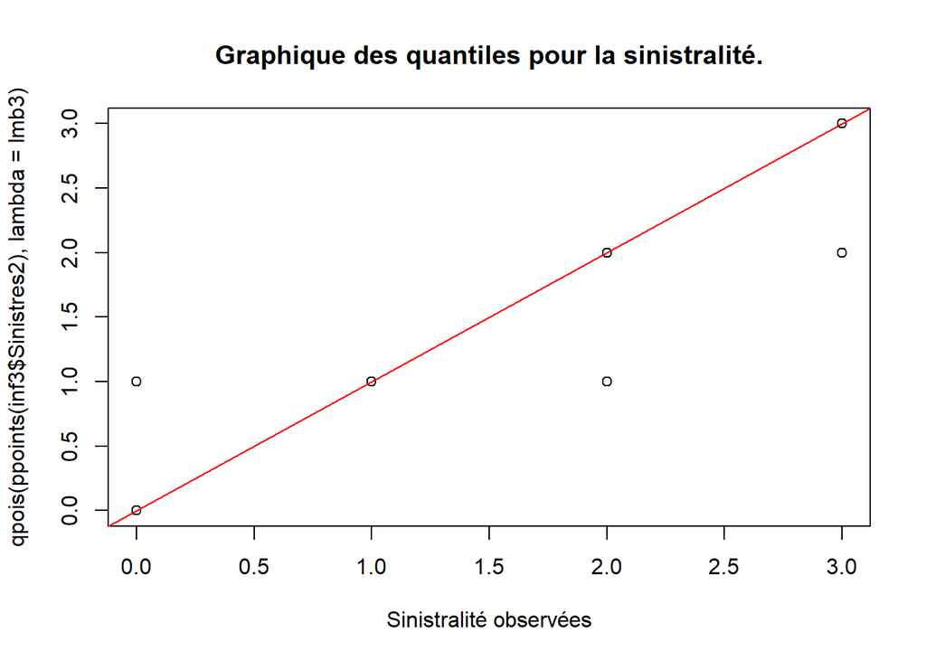

```r
lmb3 = mean(inf3$Sinistres2)
qqplot (inf3$Sinistres2, qpois(ppoints(inf3$Sinistres2), lambda = lmb3),
            xlab ="Sinistralité observées",
        main ="Graphique des quantiles pour la sinistralité.")
abline (a=0,b=1, col ="red")
```

Ce graphe est déjà plus normal pour le qqplot. On peut aussi remarquer que :

$$\lambda_3 \approx 0,1187 << \lambda_{général} \approx 0,2667$$

On capte dejà mieux les effets.

```r
echantillon3 <- sample(c(TRUE, FALSE), nrow(inf3), replace=TRUE, prob=c(0.8,0.2))
train3  <- inf3[echantillon, ]
test3   <- inf3[!echantillon, ]
```

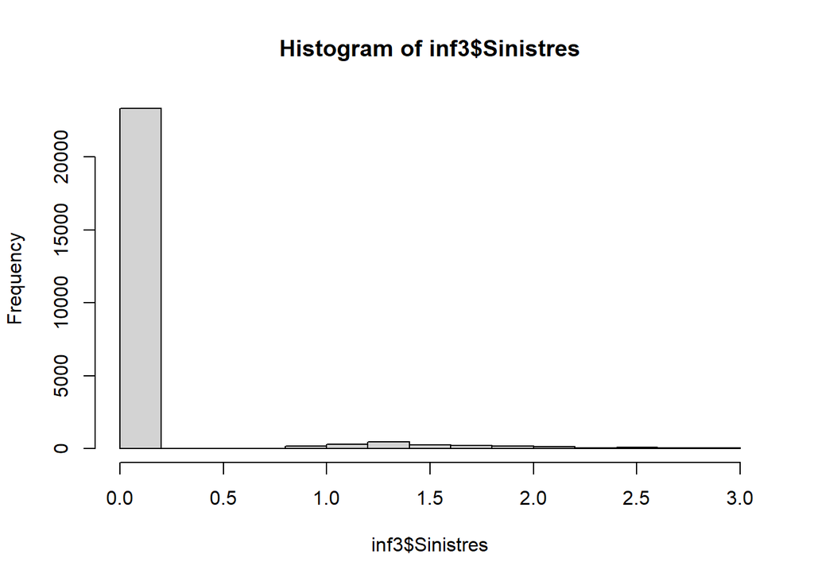

```r
hist(inf3$Sinistres)
```

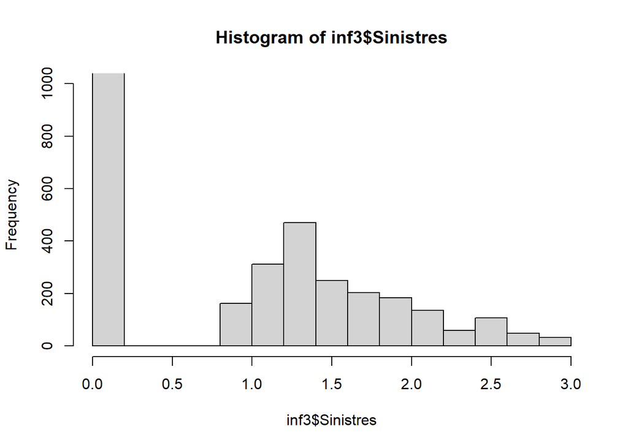

```r
hist(inf3$Sinistres, ylim=c(0,1000))
```

Avec ces courbes, on remarque qu’on risque d’être en difficulté pour capter des valeurs précises entre 1 et 3 car le poids mis en 0 est très fort.

```r
mod0_3 <- glm(Sinistres2 ~ 1, data = train3, family = poisson(link = "log"))
summary(mod0_3)
```

```
##
## Call:
## glm(formula = Sinistres2 ~ 1, family = poisson(link = "log"),
##     data = train3)
##
## Deviance Residuals:
##     Min       1Q   Median       3Q      Max
## -0.4885  -0.4885  -0.4885  -0.4885   3.6860
##
## Coefficients:
##             Estimate Std. Error z value Pr(>|z|)
## (Intercept) -2.12601    0.02032  -104.7   <2e-16 ***
## ---
## Signif. codes:  0 '***' 0.001 '**' 0.01 '*' 0.05 '.' 0.1 ' ' 1
##
## (Dispersion parameter for poisson family taken to be 1)
##
##     Null deviance: 12708  on 20307  degrees of freedom
## Residual deviance: 12708  on 20307  degrees of freedom
##   (372 observations effacées parce que manquantes)
## AIC: 16378
##
## Number of Fisher Scoring iterations: 6
```

```r
modFull_3 <- glm(Sinistres2 ~ MariStat+VehUsage+HasKmLimit+ClaimNbResp+ClaimNbNonResp+ClaimNbParking+ClaimNbFireTheft+ClaimNbWindscreen+OutUseNb+Risque+BonusMalus+DrivAge_fact+Categ, data = train3, family = poisson(link = "log"))
summary(modFull_3)
```

```
##
## Call:
## glm(formula = Sinistres2 ~ MariStat + VehUsage + HasKmLimit +
##     ClaimNbResp + ClaimNbNonResp + ClaimNbParking + ClaimNbFireTheft +
##     ClaimNbWindscreen + OutUseNb + Risque + BonusMalus + DrivAge_fact +
##     Categ, family = poisson(link = "log"), data = train3)
##
## Deviance Residuals:
##     Min       1Q   Median       3Q      Max
## -1.1601  -0.5132  -0.4559  -0.4102   4.0337
##
## Coefficients:
##                                 Estimate Std. Error z value Pr(>|z|)
## (Intercept)                    -2.631723   0.242270 -10.863  < 2e-16 ***
## MariStatOther                  -0.104452   0.062651  -1.667 0.095476 .
## VehUsagePrivate+trip to office  0.039964   0.073819   0.541 0.588246
## VehUsageProfessional            0.358172   0.085127   4.208 2.58e-05 ***
## VehUsageProfessional run        0.284531   0.124352   2.288 0.022131 *
## HasKmLimit1                    -0.189326   0.092425  -2.048 0.040517 *
## ClaimNbResp                     0.115880   0.038837   2.984 0.002848 **
## ClaimNbNonResp                  0.132850   0.029743   4.467 7.95e-06 ***
## ClaimNbParking                  0.200411   0.057044   3.513 0.000443 ***
## ClaimNbFireTheft                0.194321   0.060456   3.214 0.001308 **
## ClaimNbWindscreen               0.152876   0.026539   5.761 8.39e-09 ***
## OutUseNb                       -0.055242   0.031920  -1.731 0.083515 .
## Risque1                        -0.052674   0.115656  -0.455 0.648799
## Risque2                         0.106648   0.122115   0.873 0.382480
## Risque3                         0.202332   0.125221   1.616 0.106139
## Risque4                         0.441865   0.142846   3.093 0.001979 **
## BonusMalus                      0.003803   0.001767   2.153 0.031322 *
## DrivAge_fact(25,30]            -0.048673   0.130140  -0.374 0.708399
## DrivAge_fact(30,35]            -0.230476   0.131038  -1.759 0.078605 .
## DrivAge_fact(35,40]            -0.245070   0.135928  -1.803 0.071398 .
## DrivAge_fact(40,45]            -0.039827   0.136512  -0.292 0.770479
## DrivAge_fact(45,50]            -0.235931   0.140265  -1.682 0.092563 .
## DrivAge_fact(50,58]            -0.264517   0.134566  -1.966 0.049333 *
## DrivAge_fact(58,65]            -0.126895   0.143865  -0.882 0.377752
## DrivAge_fact(65,120]           -0.133902   0.156769  -0.854 0.393032
## Categ1                          0.402075   0.113307   3.549 0.000387 ***
## Categ2                          0.107053   0.137850   0.777 0.437402
## Categ3                          0.261825   0.104045   2.516 0.011854 *
## Categ4                          0.208438   0.137323   1.518 0.129047
## ---
## Signif. codes:  0 '***' 0.001 '**' 0.01 '*' 0.05 '.' 0.1 ' ' 1
##
## (Dispersion parameter for poisson family taken to be 1)
##
##     Null deviance: 12708  on 20307  degrees of freedom
## Residual deviance: 12418  on 20279  degrees of freedom
##   (372 observations effacées parce que manquantes)
## AIC: 16145
##
## Number of Fisher Scoring iterations: 6
```

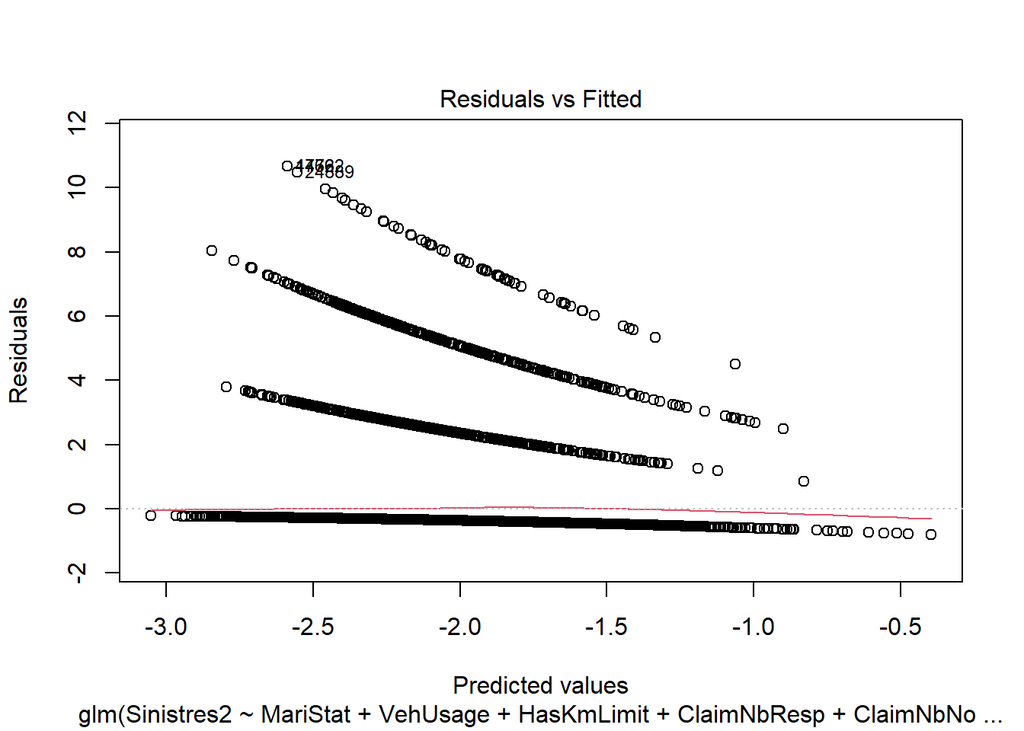

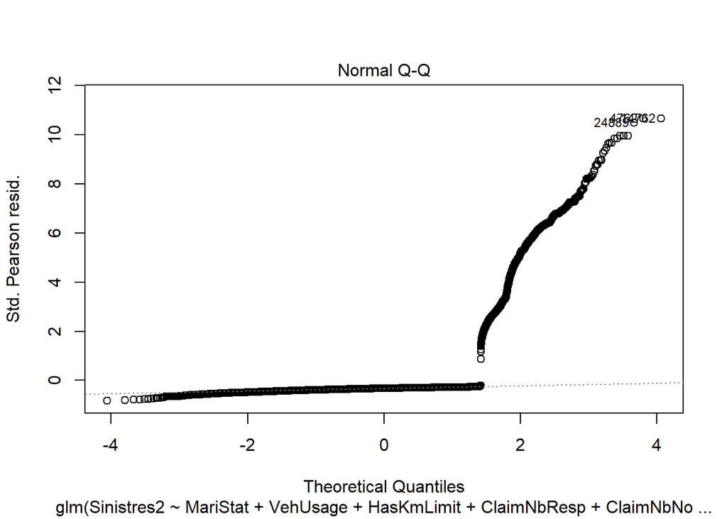

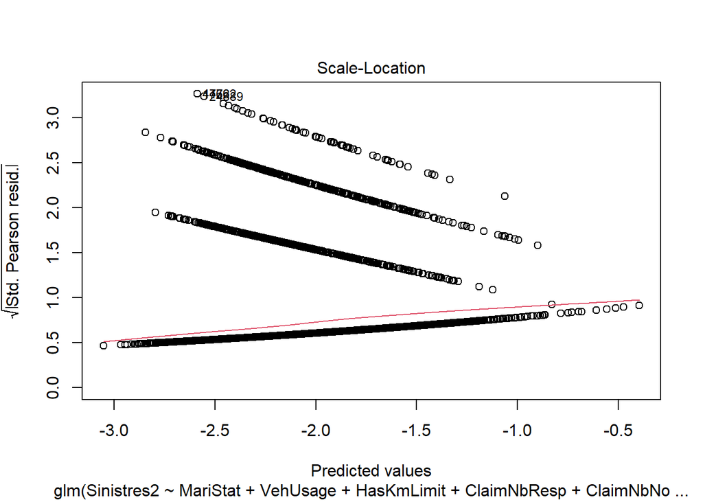

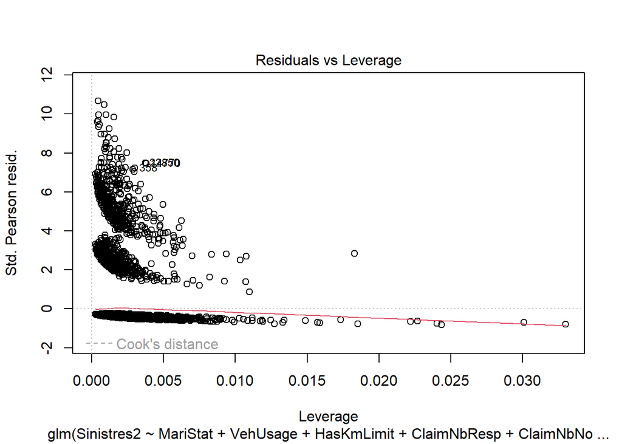

```r
plot(modFull_3)
```

```r
modQuasiPoi_3 <- glm(Sinistres2 ~ MariStat+Categ+VehUsage+HasKmLimit+ClaimNbResp+ClaimNbNonResp+ClaimNbParking+ClaimNbFireTheft+ClaimNbWindscreen+OutUseNb+RiskArea+BonusMalus+DrivAge_fact, data = train3, family = quasipoisson(link = "log"))
summary(modQuasiPoi_3)
```

```
##
## Call:
## glm(formula = Sinistres2 ~ MariStat + Categ + VehUsage + HasKmLimit +
##     ClaimNbResp + ClaimNbNonResp + ClaimNbParking + ClaimNbFireTheft +
##     ClaimNbWindscreen + OutUseNb + RiskArea + BonusMalus + DrivAge_fact,
##     family = quasipoisson(link = "log"), data = train3)
##
## Deviance Residuals:
##     Min       1Q   Median       3Q      Max
## -1.1156  -0.5154  -0.4558  -0.4096   4.0145
##
## Coefficients:
##                                  Estimate Std. Error t value Pr(>|t|)
## (Intercept)                    -13.719910 157.304139  -0.087 0.930498
## MariStatOther                   -0.101042   0.079392  -1.273 0.203140
## Categ1                           0.394023   0.143655   2.743 0.006096 **
## Categ2                           0.109465   0.174728   0.626 0.531003
## Categ3                           0.258744   0.131922   1.961 0.049853 *
## Categ4                           0.212853   0.174067   1.223 0.221411
## VehUsagePrivate+trip to office   0.044165   0.093557   0.472 0.636885
## VehUsageProfessional             0.359885   0.107861   3.337 0.000850 ***
## VehUsageProfessional run         0.288273   0.157539   1.830 0.067286 .
## HasKmLimit1                     -0.199931   0.117223  -1.706 0.088104 .
## ClaimNbResp                      0.117306   0.049152   2.387 0.017014 *
## ClaimNbNonResp                   0.131561   0.037714   3.488 0.000487 ***
## ClaimNbParking                   0.197974   0.072284   2.739 0.006171 **
## ClaimNbFireTheft                 0.189535   0.076711   2.471 0.013491 *
## ClaimNbWindscreen                0.159470   0.033893   4.705 2.55e-06 ***
## OutUseNb                        -0.057381   0.040513  -1.416 0.156686
## RiskArea2                       11.078998 157.304059   0.070 0.943852
## RiskArea3                       11.075772 157.303999   0.070 0.943868
## RiskArea4                       11.536930 157.303919   0.073 0.941535
## RiskArea5                       10.949740 157.303924   0.070 0.944506
## RiskArea6                       11.040030 157.303896   0.070 0.944049
## RiskArea7                       11.003454 157.303890   0.070 0.944234
## RiskArea8                       11.006805 157.303929   0.070 0.944217
## RiskArea9                       11.153838 157.303893   0.071 0.943473
## RiskArea10                      11.205703 157.303891   0.071 0.943211
## RiskArea11                      11.302780 157.303893   0.072 0.942719
## RiskArea12                      11.269838 157.304733   0.072 0.942886
## RiskArea13                      11.775235 157.305164   0.075 0.940330
## BonusMalus                       0.003771   0.002239   1.684 0.092114 .
## DrivAge_fact(25,30]             -0.056846   0.165189  -0.344 0.730756
## DrivAge_fact(30,35]             -0.243746   0.166328  -1.465 0.142814
## DrivAge_fact(35,40]             -0.256689   0.172496  -1.488 0.136742
## DrivAge_fact(40,45]             -0.051540   0.173212  -0.298 0.766048
## DrivAge_fact(45,50]             -0.251885   0.178011  -1.415 0.157084
## DrivAge_fact(50,58]             -0.278813   0.170788  -1.633 0.102588
## DrivAge_fact(58,65]             -0.140020   0.182494  -0.767 0.442939
## DrivAge_fact(65,120]            -0.147908   0.198884  -0.744 0.457074
## ---
## Signif. codes:  0 '***' 0.001 '**' 0.01 '*' 0.05 '.' 0.1 ' ' 1
##
## (Dispersion parameter for quasipoisson family taken to be 1.604716)
##
##     Null deviance: 12708  on 20307  degrees of freedom
## Residual deviance: 12407  on 20271  degrees of freedom
##   (372 observations effacées parce que manquantes)
## AIC: NA
##
## Number of Fisher Scoring iterations: 11
```

L’AIC n’est pas défini pour les quasi-Poisson sur R. Cependant, on remaque qu’on semble obtenir les mêmes résultats que pour la loi de Poisson normale. Y-a-t’il un problème dans le code ?

##### Prédiction

```r
estimation3 <- modFull_3$fitted.values
hist(estimation3)
```

[output not shown]

##### RMSE

```r
RMSE_train3 <- sqrt(mean(modFull_3$residuals^2))
RMSE_train3
```

```
## [1] 3.825802
```

##### Table de confusion

```r
estimation3 <- modFull_3$fitted.values
hist(estimation3)
```

[output not shown]

```r
score <- round(predict(modFull_3,train3,type="response"))
confusion.mat = table(train3$Sinistres2, score)

confusion.mat
```

```
##    score
##         0     1
##   0 18710    10
##   1   839     0
##   2   663     0
##   3    86     0
```

```r
estimation3 <- modFull_3$fitted.values
hist(estimation3)
```

[output not shown]

```r
score <- round(predict(modFull_3,test3,type="response"))
confusion.mat = table(test3$Sinistres2, score)

confusion.mat
```

```
##    score
##        0    1
##   0 4582    2
##   1  200    0
##   2  155    0
##   3   22    0
```

On obtient encore des résultats qui ne sont pas particulièrement satisfaisants.

#### <= 4 (pas concluant)

```r
inf4 = freMPL5[freMPL5$Sinistres <= 4,]
nrow(inf4)
```

```
## [1] 25459
```

```r
nrow(freMPL5)
```

```
## [1] 25722
```

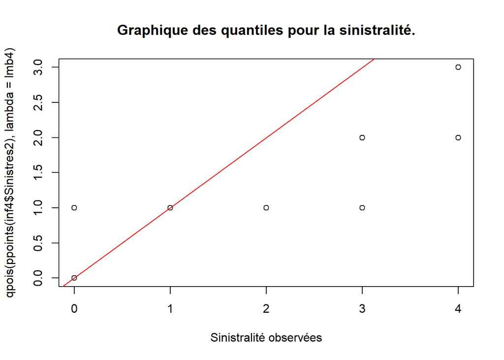

```r
lmb4 = mean(inf4$Sinistres2)
qqplot (inf4$Sinistres2, qpois(ppoints(inf4$Sinistres2), lambda = lmb4),
            xlab ="Sinistralité observées",
        main ="Graphique des quantiles pour la sinistralité.")
abline (a=0,b=1, col ="red")
```

Ce graphe semble moins bien que pour le découpage précédent (<=3). On peut aussi remarquer que :

$$\lambda_4 \approx 0.1433 << \lambda_{général} \approx 0,2667$$

```r
echantillon4 <- sample(c(TRUE, FALSE), nrow(inf4), replace=TRUE, prob=c(0.8,0.2))
train4  <- inf4[echantillon, ]
test4   <- inf4[!echantillon, ]
```

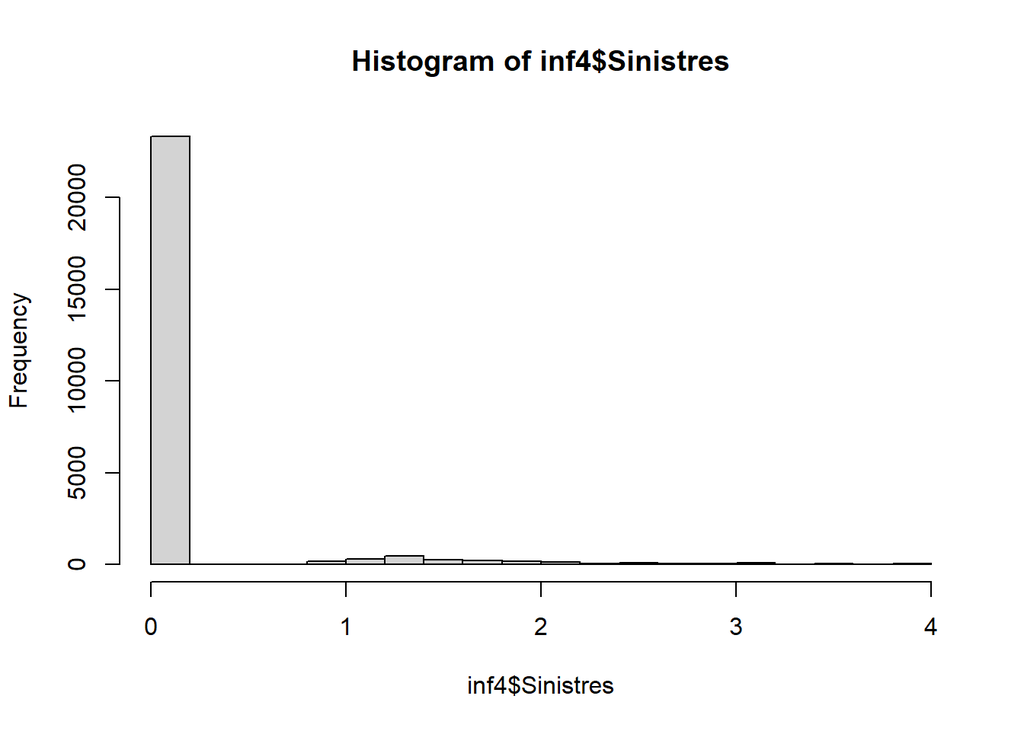

```r
hist(inf4$Sinistres)
```

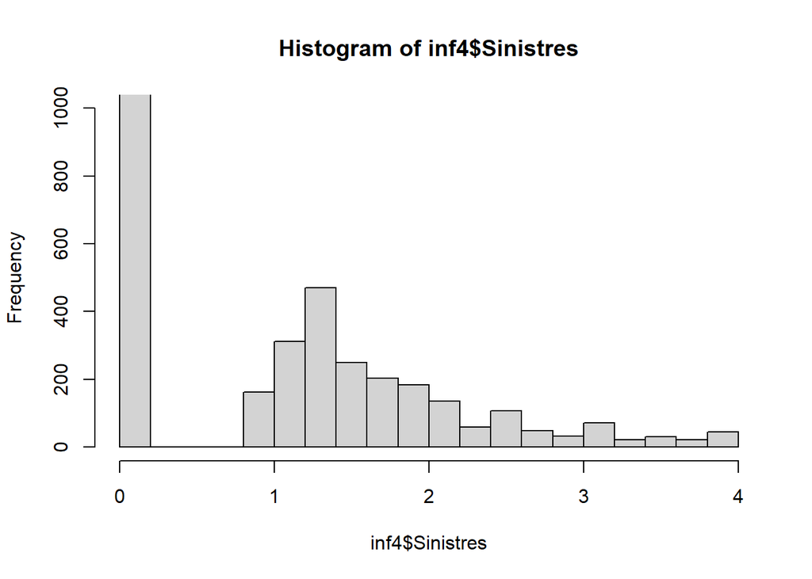

```r
hist(inf4$Sinistres, ylim=c(0,1000))
```

On peut dire à peu près les mêmes choses que pour la partie <=3.

```r
mod0_4 <- glm(Sinistres2 ~ 1, data = train4, family = poisson(link = "log"))
summary(mod0_4)
```

```
##
## Call:
## glm(formula = Sinistres2 ~ 1, family = poisson(link = "log"),
##     data = train4)
##
## Deviance Residuals:
##     Min       1Q   Median       3Q      Max
## -0.5359  -0.5359  -0.5359  -0.5359   4.3480
##
## Coefficients:
##             Estimate Std. Error z value Pr(>|z|)
## (Intercept) -1.94094    0.01845  -105.2   <2e-16 ***
## ---
## Signif. codes:  0 '***' 0.001 '**' 0.01 '*' 0.05 '.' 0.1 ' ' 1
##
## (Dispersion parameter for poisson family taken to be 1)
##
##     Null deviance: 15063  on 20463  degrees of freedom
## Residual deviance: 15063  on 20463  degrees of freedom
##   (216 observations effacées parce que manquantes)
## AIC: 19211
##
## Number of Fisher Scoring iterations: 6
```

```r
modFull_4 <- glm(Sinistres2 ~ MariStat+Categ+VehUsage+HasKmLimit+ClaimNbResp+ClaimNbNonResp+ClaimNbParking+ClaimNbFireTheft+ClaimNbWindscreen+OutUseNb+Risque+BonusMalus+DrivAge_fact, data = train4, family = poisson(link = "log"))
summary(modFull_4)
```

```
##
## Call:
## glm(formula = Sinistres2 ~ MariStat + Categ + VehUsage + HasKmLimit +
##     ClaimNbResp + ClaimNbNonResp + ClaimNbParking + ClaimNbFireTheft +
##     ClaimNbWindscreen + OutUseNb + Risque + BonusMalus + DrivAge_fact,
##     family = poisson(link = "log"), data = train4)
##
## Deviance Residuals:
##     Min       1Q   Median       3Q      Max
## -1.1538  -0.5632  -0.4988  -0.4516   4.8128
##
## Coefficients:
##                                 Estimate Std. Error z value Pr(>|z|)
## (Intercept)                    -2.722561   0.221689 -12.281  < 2e-16 ***
## MariStatOther                  -0.013178   0.057835  -0.228  0.81976
## Categ1                          0.284193   0.107712   2.638  0.00833 **
## Categ2                          0.508406   0.120530   4.218 2.46e-05 ***
## Categ3                          0.381267   0.097711   3.902 9.54e-05 ***
## Categ4                          0.247903   0.127902   1.938  0.05260 .
## VehUsagePrivate+trip to office  0.066999   0.066249   1.011  0.31187
## VehUsageProfessional            0.372044   0.076895   4.838 1.31e-06 ***
## VehUsageProfessional run        0.549329   0.109073   5.036 4.75e-07 ***
## HasKmLimit1                    -0.102106   0.081287  -1.256  0.20907
## ClaimNbResp                     0.087885   0.035478   2.477  0.01324 *
## ClaimNbNonResp                  0.120566   0.027322   4.413 1.02e-05 ***
## ClaimNbParking                  0.253669   0.050032   5.070 3.98e-07 ***
## ClaimNbFireTheft                0.164074   0.056301   2.914  0.00357 **
## ClaimNbWindscreen               0.112792   0.024571   4.591 4.42e-06 ***
## OutUseNb                       -0.020440   0.027613  -0.740  0.45916
## Risque1                        -0.044789   0.107667  -0.416  0.67741
## Risque2                         0.121059   0.113226   1.069  0.28499
## Risque3                         0.208314   0.115957   1.796  0.07242 .
## Risque4                         0.266807   0.136564   1.954  0.05073 .
## BonusMalus                      0.006216   0.001585   3.922 8.77e-05 ***
## DrivAge_fact(25,30]            -0.114985   0.112709  -1.020  0.30764
## DrivAge_fact(30,35]            -0.311392   0.114666  -2.716  0.00661 **
## DrivAge_fact(35,40]            -0.218417   0.117372  -1.861  0.06276 .
## DrivAge_fact(40,45]            -0.209833   0.120493  -1.741  0.08160 .
## DrivAge_fact(45,50]            -0.261767   0.122252  -2.141  0.03226 *
## DrivAge_fact(50,58]            -0.296331   0.116903  -2.535  0.01125 *
## DrivAge_fact(58,65]            -0.135403   0.125952  -1.075  0.28236
## DrivAge_fact(65,120]           -0.177531   0.139092  -1.276  0.20183
## ---
## Signif. codes:  0 '***' 0.001 '**' 0.01 '*' 0.05 '.' 0.1 ' ' 1
##
## (Dispersion parameter for poisson family taken to be 1)
##
##     Null deviance: 15063  on 20463  degrees of freedom
## Residual deviance: 14736  on 20435  degrees of freedom
##   (216 observations effacées parce que manquantes)
## AIC: 18939
##
## Number of Fisher Scoring iterations: 6
```

```r
modQuasiPoi_4 <- glm(Sinistres2 ~ MariStat+Categ+VehUsage+HasKmLimit+ClaimNbResp+ClaimNbNonResp+ClaimNbParking+ClaimNbFireTheft+ClaimNbWindscreen+OutUseNb+RiskArea+BonusMalus+DrivAge_fact, data = train4, family = quasipoisson(link = "log"))
summary(modQuasiPoi_4)
```

```
##
## Call:
## glm(formula = Sinistres2 ~ MariStat + Categ + VehUsage + HasKmLimit +
##     ClaimNbResp + ClaimNbNonResp + ClaimNbParking + ClaimNbFireTheft +
##     ClaimNbWindscreen + OutUseNb + RiskArea + BonusMalus + DrivAge_fact,
##     family = quasipoisson(link = "log"), data = train4)
##
## Deviance Residuals:
##     Min       1Q   Median       3Q      Max
## -1.1533  -0.5639  -0.4991  -0.4518   4.7660
##
## Coefficients:
##                                  Estimate Std. Error t value Pr(>|t|)
## (Intercept)                    -13.950681 167.477810  -0.083 0.933615
## MariStatOther                   -0.014324   0.079385  -0.180 0.856808
## Categ1                           0.283393   0.147777   1.918 0.055162 .
## Categ2                           0.511681   0.165304   3.095 0.001968 **
## Categ3                           0.385017   0.134099   2.871 0.004094 **
## Categ4                           0.253898   0.175445   1.447 0.147866
## VehUsagePrivate+trip to office   0.066663   0.090896   0.733 0.463328
## VehUsageProfessional             0.372830   0.105441   3.536 0.000407 ***
## VehUsageProfessional run         0.552772   0.149556   3.696 0.000220 ***
## HasKmLimit1                     -0.106274   0.111598  -0.952 0.340958
## ClaimNbResp                      0.088335   0.048611   1.817 0.069204 .
## ClaimNbNonResp                   0.120193   0.037475   3.207 0.001342 **
## ClaimNbParking                   0.253169   0.068599   3.691 0.000224 ***
## ClaimNbFireTheft                 0.163593   0.077336   2.115 0.034412 *
## ClaimNbWindscreen                0.113036   0.033929   3.332 0.000865 ***
## OutUseNb                        -0.020668   0.037913  -0.545 0.585668
## RiskArea2                       11.246987 167.477741   0.067 0.946459
## RiskArea3                       11.245362 167.477684   0.067 0.946467
## RiskArea4                       11.492140 167.477616   0.069 0.945294
## RiskArea5                       11.210777 167.477609   0.067 0.946631
## RiskArea6                       11.186179 167.477588   0.067 0.946748
## RiskArea7                       11.153129 167.477583   0.067 0.946905
## RiskArea8                       11.065668 167.477621   0.066 0.947321
## RiskArea9                       11.239142 167.477586   0.067 0.946496
## RiskArea10                      11.346685 167.477583   0.068 0.945985
## RiskArea11                      11.434043 167.477585   0.068 0.945570
## RiskArea12                      11.101393 167.478700   0.066 0.947151
## RiskArea13                      11.440406 167.478986   0.068 0.945540
## BonusMalus                       0.006252   0.002174   2.876 0.004030 **
## DrivAge_fact(25,30]             -0.117338   0.154871  -0.758 0.448669
## DrivAge_fact(30,35]             -0.316171   0.157623  -2.006 0.044884 *
## DrivAge_fact(35,40]             -0.219953   0.161315  -1.363 0.172740
## DrivAge_fact(40,45]             -0.211142   0.165603  -1.275 0.202328
## DrivAge_fact(45,50]             -0.264929   0.168085  -1.576 0.115004
## DrivAge_fact(50,58]             -0.297345   0.160684  -1.850 0.064257 .
## DrivAge_fact(58,65]             -0.137058   0.173087  -0.792 0.428461
## DrivAge_fact(65,120]            -0.179752   0.191118  -0.941 0.346957
## ---
## Signif. codes:  0 '***' 0.001 '**' 0.01 '*' 0.05 '.' 0.1 ' ' 1
##
## (Dispersion parameter for quasipoisson family taken to be 1.879355)
##
##     Null deviance: 15063  on 20463  degrees of freedom
## Residual deviance: 14728  on 20427  degrees of freedom
##   (216 observations effacées parce que manquantes)
## AIC: NA
##
## Number of Fisher Scoring iterations: 11
```

L’AIC n’est pas défini pour les quasi-Poisson sur R. Cependant, on remaque que les résidus sont plus importants sur la quasi-Poisson que sur la Poisson.

Nous perdons ici en précision et performance sur cette modélisation. Nous n’allons même pas tenter de regarder ce que cela donne sur l’échantillon de test.

```r
modNBFull_4 <- glm.nb(Sinistres2 ~ MariStat+Categ+VehUsage+HasKmLimit+ClaimNbResp+ClaimNbNonResp+ClaimNbParking+ClaimNbFireTheft+ClaimNbWindscreen+OutUseNb+Risque+BonusMalus+DrivAge_fact, data = train4)
summary(modNBFull_4)
```

```
##
## Call:
## glm.nb(formula = Sinistres2 ~ MariStat + Categ + VehUsage + HasKmLimit +
##     ClaimNbResp + ClaimNbNonResp + ClaimNbParking + ClaimNbFireTheft +
##     ClaimNbWindscreen + OutUseNb + Risque + BonusMalus + DrivAge_fact,
##     data = train4, init.theta = 0.1117177862, link = log)
##
## Deviance Residuals:
##     Min       1Q   Median       3Q      Max
## -0.6873  -0.4447  -0.4065  -0.3770   2.4410
##
## Coefficients:
##                                 Estimate Std. Error z value Pr(>|z|)
## (Intercept)                    -2.897754   0.350007  -8.279  < 2e-16 ***
## MariStatOther                  -0.005646   0.090386  -0.062 0.950193
## Categ1                          0.355851   0.164931   2.158 0.030961 *
## Categ2                          0.609599   0.189107   3.224 0.001266 **
## Categ3                          0.443846   0.146785   3.024 0.002496 **
## Categ4                          0.335558   0.189531   1.770 0.076649 .
## VehUsagePrivate+trip to office  0.079456   0.099273   0.800 0.423491
## VehUsageProfessional            0.400799   0.119159   3.364 0.000769 ***
## VehUsageProfessional run        0.632756   0.176250   3.590 0.000331 ***
## HasKmLimit1                    -0.078006   0.115890  -0.673 0.500881
## ClaimNbResp                     0.101353   0.056762   1.786 0.074169 .
## ClaimNbNonResp                  0.130642   0.044974   2.905 0.003675 **
## ClaimNbParking                  0.297790   0.085092   3.500 0.000466 ***
## ClaimNbFireTheft                0.187430   0.092767   2.020 0.043339 *
## ClaimNbWindscreen               0.121346   0.039833   3.046 0.002316 **
## OutUseNb                       -0.022411   0.043321  -0.517 0.604936
## Risque1                        -0.095311   0.159088  -0.599 0.549101
## Risque2                         0.068091   0.168686   0.404 0.686467
## Risque3                         0.176798   0.174537   1.013 0.311082
## Risque4                         0.210731   0.211314   0.997 0.318648
## BonusMalus                      0.007474   0.002613   2.860 0.004236 **
## DrivAge_fact(25,30]            -0.102538   0.189501  -0.541 0.588441
## DrivAge_fact(30,35]            -0.271004   0.188663  -1.436 0.150877
## DrivAge_fact(35,40]            -0.158590   0.194574  -0.815 0.415037
## DrivAge_fact(40,45]            -0.142151   0.198826  -0.715 0.474638
## DrivAge_fact(45,50]            -0.209657   0.200857  -1.044 0.296572
## DrivAge_fact(50,58]            -0.262687   0.193335  -1.359 0.174238
## DrivAge_fact(58,65]            -0.109227   0.207957  -0.525 0.599419
## DrivAge_fact(65,120]           -0.135687   0.224409  -0.605 0.545415
## ---
## Signif. codes:  0 '***' 0.001 '**' 0.01 '*' 0.05 '.' 0.1 ' ' 1
##
## (Dispersion parameter for Negative Binomial(0.1117) family taken to be 1)
##
##     Null deviance: 5737.4  on 20463  degrees of freedom
## Residual deviance: 5590.1  on 20435  degrees of freedom
##   (216 observations effacées parce que manquantes)
## AIC: 15970
##
## Number of Fisher Scoring iterations: 1
##
##
##               Theta:  0.11172
##           Std. Err.:  0.00497
##
##  2 x log-likelihood:  -15910.07500
```

```r
modNB0_4 <- glm.nb(Sinistres2 ~ 1, data = train4)
summary(modNB0_4)
```

```
##
## Call:
## glm.nb(formula = Sinistres2 ~ 1, data = train4, init.theta = 0.1033136349,
##     link = log)
##
## Deviance Residuals:
##     Min       1Q   Median       3Q      Max
## -0.4243  -0.4243  -0.4243  -0.4243   1.8847
##
## Coefficients:
##             Estimate Std. Error z value Pr(>|z|)
## (Intercept) -1.94094    0.02852  -68.06   <2e-16 ***
## ---
## Signif. codes:  0 '***' 0.001 '**' 0.01 '*' 0.05 '.' 0.1 ' ' 1
##
## (Dispersion parameter for Negative Binomial(0.1033) family taken to be 1)
##
##     Null deviance: 5525.5  on 20463  degrees of freedom
## Residual deviance: 5525.5  on 20463  degrees of freedom
##   (216 observations effacées parce que manquantes)
## AIC: 16058
##
## Number of Fisher Scoring iterations: 1
##
##
##               Theta:  0.10331
##           Std. Err.:  0.00451
##
##  2 x log-likelihood:  -16054.17600
```

#### Seulement avec les sinistres >1 (pas concluant)

##### Choix de partition

```r
cout = freMPL5[freMPL5$Sinistres>0,]
```

Nous allons créer un modèle de Poisson pour les variables qui ont au moins un Sinistre dans l’année pour ensuite faire une loi mélange (une loi bernouilli pour donner s’il y a au moins un sinistre ou pas, puis une loi de Poisson dans le cas où il y a au moins un sinistre pour determiner le nombre de sinistres). Tracons dans un premier temps les graphes quantiles-quantiles

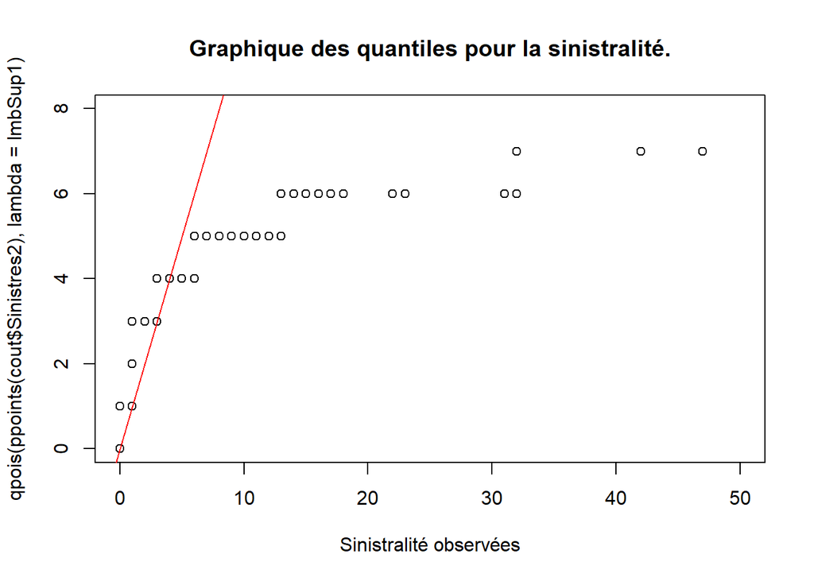

```r
lmbSup1 = mean(cout$Sinistres2) -1
qqplot(cout$Sinistres2-1, qpois(ppoints(cout$Sinistres2), lambda = lmbSup1), xlab ="Sinistralité observées", main ="Graphique des quantiles pour la sinistralité.", xlim=c(0,50))
abline (a=0,b=1, col ="red")
```

Encore une fois, on a une surdispersion assez forte pour les grandes valeurs, ce qui peut être dû à quelques valeurs extrèmes.

Remarque pratique :

Par ailleurs, on pourra considérer que ces valeurs sont dû au fait qu’on divise parfois 1 (=ClaimInd) par un Exposure très petit. Dans la réalité, l’assuré n’a pas plus de 10 ou 20 sinistres par an.

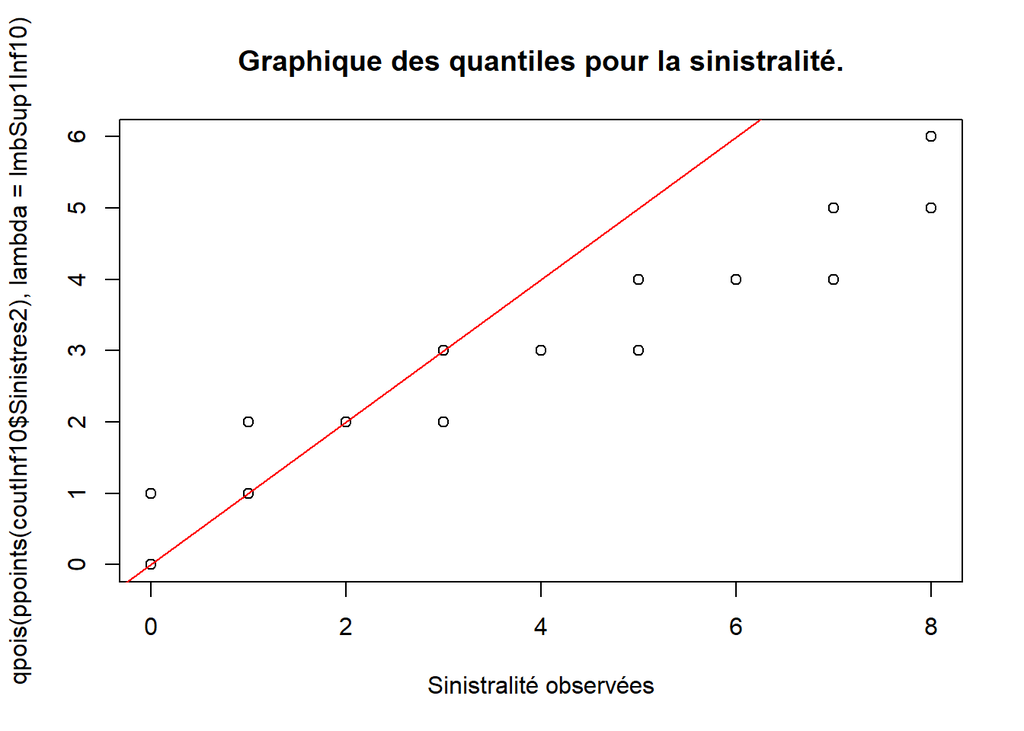

```r
coutInf10 = cout[cout$Sinistres2<10,]
lmbSup1Inf10 = mean(coutInf10$Sinistres2) -1
qqplot(coutInf10$Sinistres2-1, qpois(ppoints(coutInf10$Sinistres2), lambda = lmbSup1Inf10), xlab ="Sinistralité observées", main ="Graphique des quantiles pour la sinistralité.")
abline (a=0,b=1, col ="red")
```

On remarque encore une fois qu’on s’éloigne légèrement d’une loi de Poisson dans les quantiles.

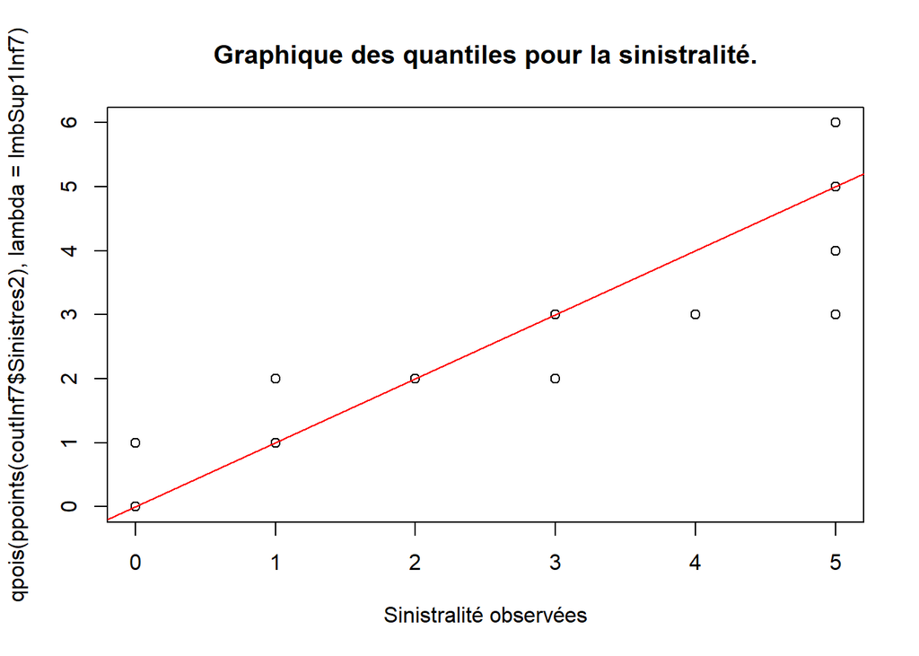

```r
coutInf7 = cout[cout$Sinistres2<7,]
lmbSup1Inf7 = mean(coutInf10$Sinistres2) -1
qqplot(coutInf7$Sinistres2 -1, qpois(ppoints(coutInf7$Sinistres2), lambda = lmbSup1Inf7), xlab ="Sinistralité observées", main ="Graphique des quantiles pour la sinistralité.")
abline (a=0,b=1, col ="red")
```

C’est peut-être avec ces caractéristiques que le graphe quantile-quantile est le mieux. Regardons ce qu’il en est de la modélisation.

##### Modélisation

```r
echantillonSup1Inf7 <- sample(c(TRUE, FALSE), nrow(coutInf7), replace=TRUE, prob=c(0.8,0.2))
train_1_7  <- coutInf7[echantillonSup1Inf7, ]
test_1_7   <- coutInf7[!echantillonSup1Inf7, ]
```

```r
mod_1_7 <- glm(Sinistres2 -1 ~ MariStat+Categ+VehUsage+HasKmLimit+ClaimNbResp+ClaimNbNonResp+ClaimNbParking+ClaimNbFireTheft+ClaimNbWindscreen+OutUseNb+Risque+BonusMalus+DrivAge_fact, data = train_1_7, family = poisson(link = "log"))
summary(mod_1_7)
```

```
##
## Call:
## glm(formula = Sinistres2 - 1 ~ MariStat + Categ + VehUsage +
##     HasKmLimit + ClaimNbResp + ClaimNbNonResp + ClaimNbParking +
##     ClaimNbFireTheft + ClaimNbWindscreen + OutUseNb + Risque +
##     BonusMalus + DrivAge_fact, family = poisson(link = "log"),
##     data = train_1_7)
##
## Deviance Residuals:
##     Min       1Q   Median       3Q      Max
## -1.8498  -1.2971  -0.0961   0.2788   3.3989
##
## Coefficients:
##                                 Estimate Std. Error z value Pr(>|z|)
## (Intercept)                     0.127849   0.289823   0.441  0.65912
## MariStatOther                   0.050479   0.079279   0.637  0.52430
## Categ1                         -0.236927   0.134553  -1.761  0.07827 .
## Categ2                         -0.082159   0.156396  -0.525  0.59936
## Categ3                         -0.095566   0.124152  -0.770  0.44145
## Categ4                         -0.229083   0.174703  -1.311  0.18977
## VehUsagePrivate+trip to office -0.019466   0.086254  -0.226  0.82144
## VehUsageProfessional           -0.113480   0.104008  -1.091  0.27524
## VehUsageProfessional run        0.230381   0.140861   1.636  0.10194
## HasKmLimit1                     0.273580   0.101704   2.690  0.00715 **
## ClaimNbResp                     0.113567   0.044998   2.524  0.01161 *
## ClaimNbNonResp                  0.043067   0.035621   1.209  0.22665
## ClaimNbParking                  0.012895   0.074031   0.174  0.86172
## ClaimNbFireTheft                0.061613   0.071565   0.861  0.38927
## ClaimNbWindscreen               0.036337   0.032237   1.127  0.25966
## OutUseNb                        0.018508   0.034413   0.538  0.59071
## Risque1                         0.114195   0.140428   0.813  0.41611
## Risque2                         0.197085   0.147656   1.335  0.18196
## Risque3                         0.103283   0.152260   0.678  0.49756
## Risque4                         0.032256   0.180414   0.179  0.85810
## BonusMalus                     -0.001746   0.002085  -0.837  0.40233
## DrivAge_fact(25,30]            -0.161395   0.149966  -1.076  0.28183
## DrivAge_fact(30,35]            -0.007893   0.147519  -0.054  0.95733
## DrivAge_fact(35,40]            -0.208995   0.155066  -1.348  0.17773
## DrivAge_fact(40,45]            -0.197607   0.157594  -1.254  0.20988
## DrivAge_fact(45,50]            -0.293975   0.161132  -1.824  0.06809 .
## DrivAge_fact(50,58]            -0.307011   0.156979  -1.956  0.05049 .
## DrivAge_fact(58,65]            -0.324129   0.168094  -1.928  0.05382 .
## DrivAge_fact(65,120]           -0.389718   0.190618  -2.044  0.04091 *
## ---
## Signif. codes:  0 '***' 0.001 '**' 0.01 '*' 0.05 '.' 0.1 ' ' 1
##
## (Dispersion parameter for poisson family taken to be 1)
##
##     Null deviance: 2586.9  on 1848  degrees of freedom
## Residual deviance: 2528.5  on 1820  degrees of freedom
## AIC: 4929.7
##
## Number of Fisher Scoring iterations: 5
```

```r
mod_Vide<- glm(Sinistres2 -1 ~ 1, data = train_1_7, family = poisson(link = "log"))
summary(mod_Vide)
```

```
##
## Call:
## glm(formula = Sinistres2 - 1 ~ 1, family = poisson(link = "log"),
##     data = train_1_7)
##
## Deviance Residuals:
##      Min        1Q    Median        3Q       Max
## -1.34522  -1.34522   0.09839   0.09839   2.98400
##
## Coefficients:
##             Estimate Std. Error z value Pr(>|z|)
## (Intercept) -0.10003    0.02445  -4.091 4.29e-05 ***
## ---
## Signif. codes:  0 '***' 0.001 '**' 0.01 '*' 0.05 '.' 0.1 ' ' 1
##
## (Dispersion parameter for poisson family taken to be 1)
##
##     Null deviance: 2586.9  on 1848  degrees of freedom
## Residual deviance: 2586.9  on 1848  degrees of freedom
## AIC: 4932.2
##
## Number of Fisher Scoring iterations: 5
```

```r
modBoth_1_7 = step(mod_1_7, mod_Vide, trace=F, direction = c('both'))
summary(modBoth_1_7)
```

```
##
## Call:
## glm(formula = Sinistres2 - 1 ~ Categ + VehUsage + HasKmLimit +
##     ClaimNbResp, family = poisson(link = "log"), data = train_1_7)
##
## Deviance Residuals:
##     Min       1Q   Median       3Q      Max
## -1.7725  -1.3569  -0.0143   0.2512   3.3196
##
## Coefficients:
##                                 Estimate Std. Error z value Pr(>|z|)
## (Intercept)                     0.017363   0.139213   0.125  0.90075
## Categ1                         -0.271348   0.133821  -2.028  0.04259 *
## Categ2                         -0.082953   0.155567  -0.533  0.59387
## Categ3                         -0.089955   0.123533  -0.728  0.46650
## Categ4                         -0.369224   0.151639  -2.435  0.01490 *
## VehUsagePrivate+trip to office -0.002858   0.084766  -0.034  0.97310
## VehUsageProfessional           -0.113168   0.101826  -1.111  0.26640
## VehUsageProfessional run        0.250920   0.138150   1.816  0.06933 .
## HasKmLimit1                     0.258009   0.100071   2.578  0.00993 **
## ClaimNbResp                     0.089701   0.040180   2.232  0.02558 *
## ---
## Signif. codes:  0 '***' 0.001 '**' 0.01 '*' 0.05 '.' 0.1 ' ' 1
##
## (Dispersion parameter for poisson family taken to be 1)
##
##     Null deviance: 2586.9  on 1848  degrees of freedom
## Residual deviance: 2548.9  on 1839  degrees of freedom
## AIC: 4912.2
##
## Number of Fisher Scoring iterations: 5
```

La méthode nous a enlevé presque toutes les variables. Donc nous n’allons clairement pas choisir cette modélisation.

## c) Etude des résidus

A partir des différentes modélisations ci-dessus et par une logique de sélection que nous expliciterons plus en profondeur dans le rendu écrit (LateX) du mémoire, nous allons conserver le modèle obtenu par un GLM de Poisson sur toutes les observations et les interactions. Nous allons donc effectuer une étude des résidus pour vérifier que nos données collent bien aux hypothèses du modèle.

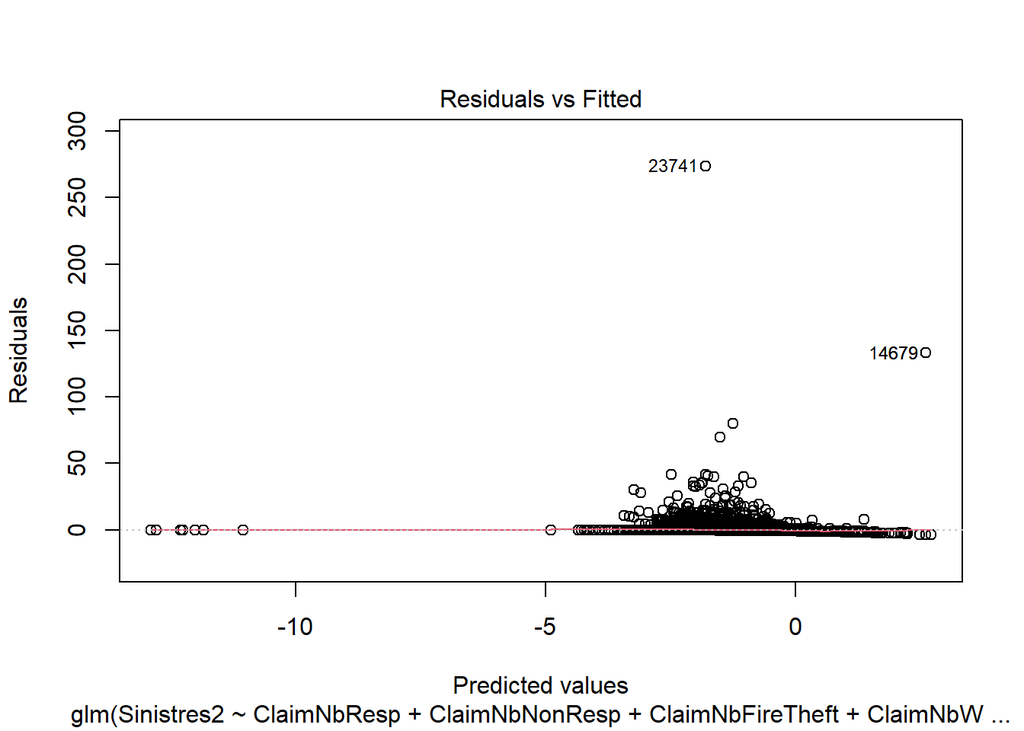

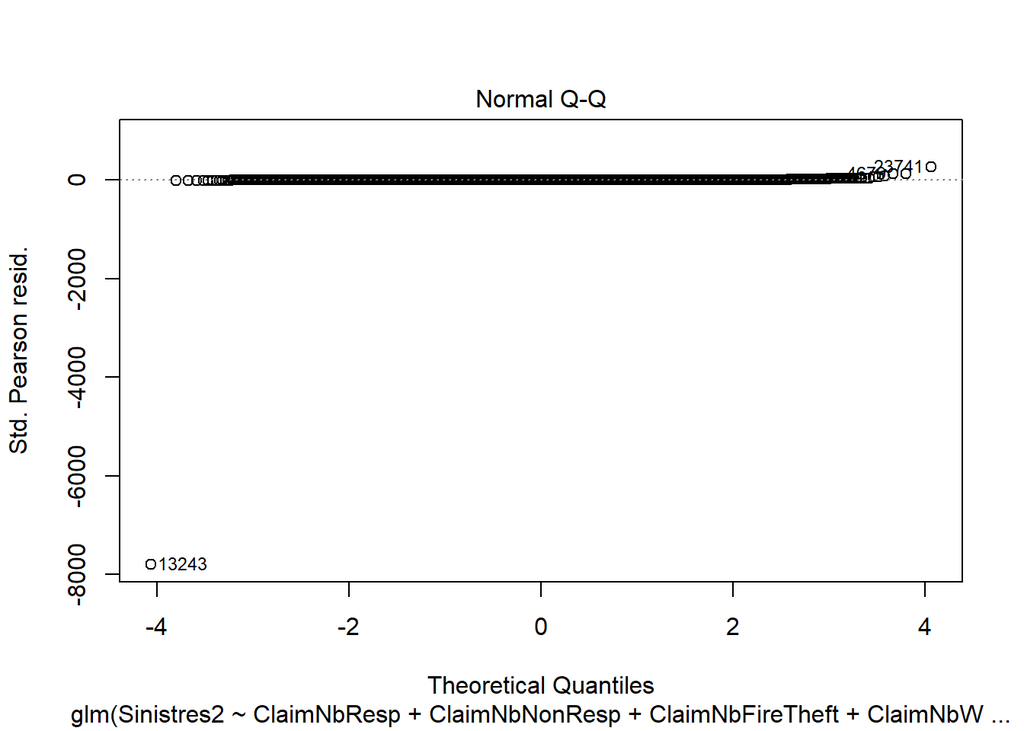

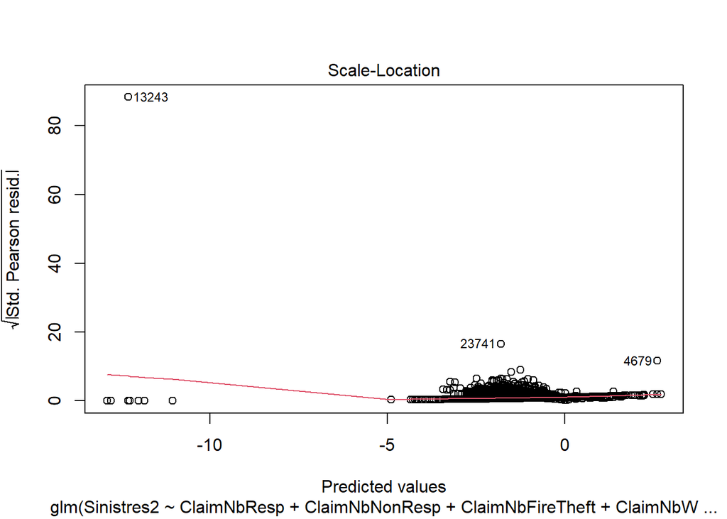

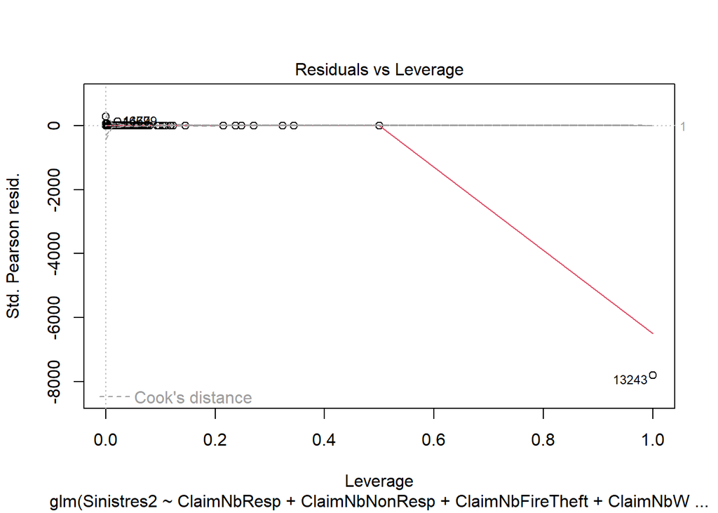

```r
residus = resid(mod_final)
plot(mod_final)
```